# Household Travel Survey: Vehicle Ownership

Mary Richards

December 09 2020

This report presents preliminary findings for household vehicle ownership trends based on the Household Travel Survey (2017 and 2019), a survey conducted every other year to determine travel patterns for individuals living within PSRC’s four-county jurisdiction.

## 1. Background Information

This section describes the different explanatory and outcome variables.

## 2. Outcome Variables

The two outcome variables from these models are at the household level (by household id):

1. Vehicle count - the number of vehicles owned (reported by survey respondents)
2. Vehicle access - the number of household vehicles owned in relation to the number of workers in each household

### a. Household Vehicle Count

Survey Responses:  
*“How many motor vehicles (in working order) are there in your household?”*

|  | Overall (N=6319) |
| --- | --- |
| vehcount_ordered |  |
| 0 (no vehicles) | 1111 (18%) |
| 1 | 3033 (48%) |
| 2 | 1681 (27%) |
| 3 | 349 (6%) |
| 4 | 101 (2%) |
| 5 | 34 (1%) |
| 6 | 5 (0%) |
| 7 | 2 (0%) |
| 8 | 1 (0%) |
| 9 | 1 (0%) |
| 10 or more vehicles | 1 (0%) |

```
## # A tibble: 11 x 5
##    vehcount_ordered        n sum_wt_comb perc_comb   MOE
##    <fct>               <int>       <dbl>     <dbl> <dbl>
##  1 0 (no vehicles)      1111      129694      7.83  1.04
##  2 1                    3033      512485     30.9   1.04
##  3 2                    1681      624905     37.7   1.04
##  4 3                     349      267392     16.1   1.04
##  5 4                     101       63642      3.84  1.04
##  6 5                      34       45050      2.72  1.04
##  7 6                       5        7367      0.44  1.04
##  8 7                       2        2626      0.16  1.04
##  9 8                       1         298      0.02  1.04
## 10 9                       1         385      0.02  1.04
## 11 10 or more vehicles     1        2910      0.18  1.04
```

Based on survey responses, there is a very small number of households with more than 3 vehicles, so these households are grouped together.

*Number of workers by household id*

|  | Overall (N=6319) |
| --- | --- |
| vehicle_group |  |
| 0 | 1111 (18%) |
| 1 | 3033 (48%) |
| 2 | 1681 (27%) |
| 3 | 494 (8%) |

```
## # A tibble: 4 x 5
##   vehicle_group     n sum_wt_comb perc_comb   MOE
##   <fct>         <int>       <dbl>     <dbl> <dbl>
## 1 0              1111      129694      7.83  1.04
## 2 1              3033      512485     30.9   1.04
## 3 2              1681      624905     37.7   1.04
## 4 3               494      389671     23.5   1.04
```

### b. Household Vehicle Access

This variable is based on the number of household vehicles (explained above) and the number of workers within the household.

|  | Overall (N=6319) |
| --- | --- |
| numworkers |  |
| 0 | 1190 (19%) |
| 1 | 2920 (46%) |
| 2 | 2054 (33%) |
| 3 | 131 (2%) |
| 4 | 20 (0%) |
| 5 | 4 (0%) |

```
## # A tibble: 6 x 5
##   numworkers     n sum_wt_comb perc_comb   MOE
##   <fct>      <int>       <dbl>     <dbl> <dbl>
## 1 0           1190      324848     19.6   1.04
## 2 1           2920      624264     37.7   1.04
## 3 2           2054      573546     34.6   1.04
## 4 3            131      107521      6.49  1.04
## 5 4             20       23914      1.44  1.04
## 6 5              4        2662      0.16  1.04
```

Based on survey responses, there is a very small number of households with more than 3 workers, so these households are grouped together

|  | Overall (N=6319) |
| --- | --- |
| numworkers_group |  |
| 0 | 1190 (19%) |
| 1 | 2920 (46%) |
| 2 | 2054 (33%) |
| 3 | 155 (2%) |

```
## # A tibble: 4 x 5
##   numworkers_group     n sum_wt_comb perc_comb   MOE
##   <fct>            <int>       <dbl>     <dbl> <dbl>
## 1 0                 1190      324848     19.6   1.04
## 2 1                 2920      624264     37.7   1.04
## 3 2                 2054      573546     34.6   1.04
## 4 3                  155      134097      8.09  1.04
```

**Vehicle Access is calculated by comparing the number of vehicles and the number of workers per household**

- *limited access*: vehicles < workers
- *equal access*: vehicles = workers
- *good access*: vehicles > workers

|  | Overall (N=6319) |
| --- | --- |
| hh_veh_access |  |
| Reduced access | 4632 (73%) |
| Equal access | 1233 (20%) |
| Good access | 454 (7%) |

Although vehicle access is an interesting measurement to explore, it requires a few levels of aggregation and adjustment, which could introduce error or oversimplification. Therefore, analysis will be based on household vehicle ownership, or the count of vehicles per household.

## 3. Explanatory or predictor variables

There are many personal and household characteristics that can contribute to vehicle ownership at the household level. Based on these considerations and the data available through survey responses, the following table will attempt to match the person-level and household-level characteristics with responses provided by the survey participants. The data listed in the right column are from the in-house person (p) and household (h) views, available through Elmer, or describe an externally-sourced dataset (e).

Vehicle-ownership Considerations

Survey Variables

1. Income

*hhincome_broad (p/h), hhincome_detailed (p/h)*

2. Gender

*gender (p)*

3. Age

*age (p), age_category (p)*

4. Household size

*hhsize (p/h)*

5. Number of licensed (or licensed age) individuals

*license (p)*

6. Occupation

*employment (p), jobs_count (p)*

7. Educational Attainment

*education (p)*

8. Number of workers

*numworkers (h)*

9. Household lifecycle or age composition of household members

*lifecycle (p/h)*

10. Race or ethnicity

*race_category (p)*

11. Physical disabilities

*?*

12. Housing type

*rent_own (h), res_type (h)*

13. Housing or work location and proximity to transit

*final_home_rgcnum (h), seattle_home (h)*

14. Commuting patterns

*commute_freq (p), commute_mode (p), commute_dur (p), telecommute_freq (p)*

15. Quality of transit options available

*transit score by block group (e)*

16. Housing proximity to services

*displacement risk index (e)*

17. Environmental consciousness

*?*

Because the outcome variable is household vehicle ownership, the person-level variables need to be aggregated to the household level. With this in mind, gender and employment type were removed from this analysis. The number of jobs per person was included.  
The table below illustrates the person-level variables related to vehicle ownership and the way in which they were aggregated:

Person-level variables

Aggregation method(s)

Number of licensed (or licensed age) individuals

sum

Number of jobs

sum

Educational Attainment

min, max

Commuting Patterns

- Distance (mi) by automobile
- Time (?) by automobile
- Commute frequency (days/week)

mean

mean

min, max

In addition to these variables, two additional ones were calculated:

- Number of household jobs per worker (sum of household jobs/numworkers)
- Number of household commute trips per week (sum of household commute trips/(numworkers*5))

### a. Univariate analysis

The dependent variable or outcome will be vehicle ownership (*“vehicle_group”*: 0, 1, 2, 3+) and the independent or explanatory variables will be from the list above. Because the vehicle ownership is ordinal, an ordered logit model will be applied.

The following section will introduce descriptive statistics for each of the explanatory variables, followed by analysis. For an overview of the results from these individual analyses, please skip to section 3b.

#### *1. Income*

|  | Overall (N=6319) |
| --- | --- |
| hhincomeb_reordered |  |
| Under $25,000 | 633 (10%) |
| $25,000-$49,999 | 937 (15%) |
| $50,000-$74,999 | 948 (15%) |
| $75,000-$99,999 | 835 (13%) |
| $100,000 or more | 2545 (40%) |
| Prefer not to answer | 421 (7%) |

| hhincomeb_reordered | Percentage_0 | Percentage_1 | Percentage_2 | Percentage_3 | Total_0 | Total_1 | Total_2 | Total_3 | Count_0 | Count_1 | Count_2 | Count_3 | sample_size | MOE_Percent |
| --- | --- | --- | --- | --- | --- | --- | --- | --- | --- | --- | --- | --- | --- | --- |
| $100,000 or more | 2.105206 | 15.48069 | 45.803297 | 36.610804 | 13962.697 | 102675.10 | 303788.60 | 242819.75 | 242 | 1075 | 928 | 300 | 2545 | 1.630392 |
| $25,000-$49,999 | 11.689098 | 43.19336 | 36.549599 | 8.567947 | 28316.046 | 104632.96 | 88538.92 | 20755.27 | 245 | 525 | 140 | 27 | 937 | 2.686990 |
| $50,000-$74,999 | 7.141843 | 45.53108 | 32.026498 | 15.300581 | 17458.994 | 111305.56 | 78292.18 | 37403.90 | 162 | 522 | 210 | 54 | 948 | 2.671356 |
| $75,000-$99,999 | 3.498465 | 30.11401 | 42.230896 | 24.156634 | 7142.927 | 61484.71 | 86224.15 | 49321.36 | 98 | 433 | 235 | 69 | 835 | 2.846379 |
| Prefer not to answer | 3.084233 | 29.88920 | 39.503767 | 27.522801 | 3987.139 | 38639.22 | 51068.44 | 35580.07 | 65 | 195 | 125 | 36 | 421 | 4.008620 |
| Under $25,000 | 33.933469 | 54.07767 | 9.802108 | 2.186754 | 58826.180 | 93747.64 | 16992.68 | 3790.90 | 299 | 283 | 43 | 8 | 633 | 3.269144 |

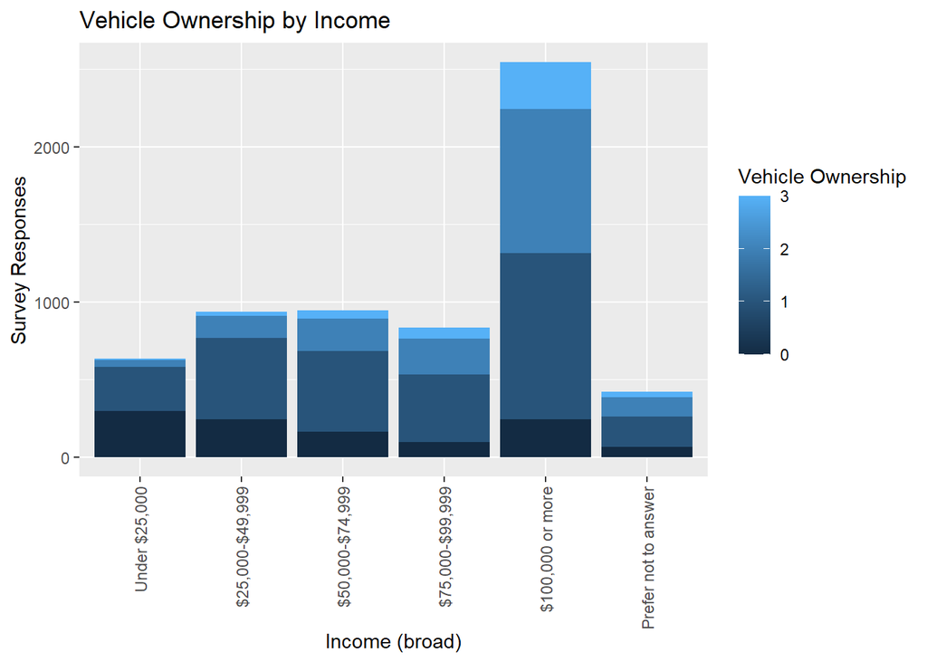

Reference group: Under $25,000

```
##                                      Value Std. Error   t value       p-value
## explanatory$25,000-$49,999       0.8917954 0.09892096  9.015232  1.964551e-19
## explanatory$50,000-$74,999       1.4340211 0.09985382 14.361204  9.063829e-47
## explanatory$75,000-$99,999       1.8305651 0.10302277 17.768549  1.238541e-70
## explanatory$100,000 or more      2.2576980 0.08956056 25.208620 3.222315e-140
## explanatoryPrefer not to answer  1.8028099 0.12271766 14.690714  7.393120e-49
## 0|1                             -0.0958170 0.07655692 -1.251579  2.107235e-01
## 1|2                              2.3507778 0.08356925 28.129699 4.245880e-174
## 2|3                              4.2655232 0.09376520 45.491539  0.000000e+00
##                                 simp p-value
## explanatory$25,000-$49,999            0.0000
## explanatory$50,000-$74,999            0.0000
## explanatory$75,000-$99,999            0.0000
## explanatory$100,000 or more           0.0000
## explanatoryPrefer not to answer       0.0000
## 0|1                                   0.2107
## 1|2                                   0.0000
## 2|3                                   0.0000
```

**Vehicle Ownership by Income**

|  | *Dependent variable:* |
| --- | --- |
|  | outcome |
| 49,999 | 0.892*** |
|  | (0.099) |
| 74,999 | 1.434*** |
|  | (0.100) |
| 99,999 | 1.831*** |
|  | (0.103) |
| 100,000 or more | 2.258*** |
|  | (0.090) |
| explanatoryPrefer not to answer | 1.803*** |
|  | (0.123) |
| Observations | 6,319 |
| *Note:* | <sup>⋆</sup>p<0.1; <sup>⋆⋆</sup>p<0.05; <sup>⋆⋆⋆</sup>p<0.01 |

In reference to the households making under $25k, households in higher income categories are more likely to own more vehicles. This positive association between household income and household vehicle ownership is statistically significant.

#### *2. Age/Lifecycle*

Person-level ages are likely to influence vehicle ownership, but because the variable of interest is vehicle ownership, the household age composition or household lifecycle will be evaluated.

Households were organized into four categories based on the composition and age of people in the household:

- *Households with children:* any household with at least one member under age 18
- *Households with younger adults:* any household without children where all adults are age 18-34
- *Households with older adults:* any household without children where all adults are age 18-64 and at least one adult is age 35-64
- *Households with seniors:* any household with at one adult age 65 and older

  |  | Overall (N=6319) |
  | --- | --- |
  | lifecycle |  |
  | Household includes children age 5-17 | 513 (8%) |
  | Household includes children under 5 | 518 (8%) |
  | Household size = 1, Householder age 35 - 64 | 1222 (19%) |
  | Household size = 1, Householder age 65+ | 525 (8%) |
  | Household size = 1, Householder under age 35 | 863 (14%) |
  | Household size > 1, Householder age 35 - 64 | 1095 (17%) |
  | Household size > 1, Householder age 65+ | 536 (8%) |
  | Household size > 1, Householder under age 35 | 1047 (17%) |

  Because of the large number of categories - accounting for both size and age, they are reduced to reflect only age ranges

  |  | Overall (N=6319) |
  | --- | --- |
  | hh_lifecycle |  |
  | Under age 35 | 1910 (30%) |
  | Age 35-64 | 2317 (37%) |
  | Age 65+ | 1061 (17%) |
  | With children under 5 | 518 (8%) |
  | With children age 5-17 | 513 (8%) |

| hh_lifecycle | Percentage_0 | Percentage_1 | Percentage_2 | Percentage_3 | Total_0 | Total_1 | Total_2 | Total_3 | Count_0 | Count_1 | Count_2 | Count_3 | sample_size | MOE_Percent |
| --- | --- | --- | --- | --- | --- | --- | --- | --- | --- | --- | --- | --- | --- | --- |
| Age 35-64 | 10.2718636 | 35.42334 | 28.30109 | 26.003704 | 54996.879 | 189661.12 | 151527.69 | 139227.18 | 427 | 1163 | 529 | 198 | 2317 | 1.708728 |
| Age 65+ | 6.7513583 | 33.65705 | 33.62075 | 25.970841 | 22970.012 | 114510.70 | 114387.23 | 88360.08 | 156 | 499 | 291 | 115 | 1061 | 2.525098 |
| Under age 35 | 16.0654874 | 46.52870 | 31.48164 | 5.924173 | 48082.586 | 139256.30 | 94221.76 | 17730.53 | 501 | 1037 | 330 | 42 | 1910 | 1.881998 |
| With children age 5-17 | 0.8500118 | 14.36484 | 49.34866 | 35.436489 | 2597.304 | 43893.35 | 150790.26 | 108280.09 | 15 | 152 | 252 | 94 | 513 | 3.631426 |
| With children under 5 | 0.5941147 | 14.27629 | 64.66386 | 20.465730 | 1047.200 | 25163.73 | 113978.04 | 36073.38 | 12 | 182 | 279 | 45 | 518 | 3.613858 |

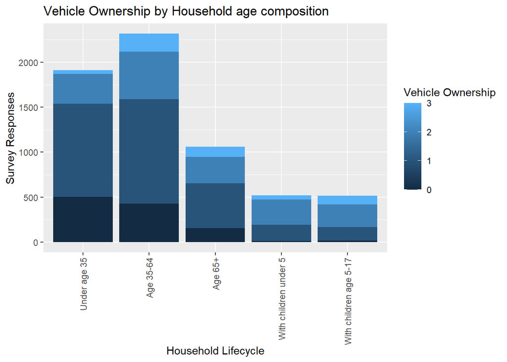

Reference group: Under age 35

```
##                                        Value Std. Error    t value
## explanatoryAge 35-64               0.5877341 0.05927761   9.914942
## explanatoryAge 65+                 0.9023492 0.07375077  12.235116
## explanatoryWith children under 5   1.7231123 0.09093546  18.948739
## explanatoryWith children age 5-17  2.0239324 0.09412203  21.503281
## 0|1                               -0.9874235 0.04618040 -21.381873
## 1|2                                1.3761713 0.04826917  28.510356
## 2|3                                3.3324106 0.06516364  51.139113
##                                         p-value simp p-value
## explanatoryAge 35-64               3.584629e-23            0
## explanatoryAge 65+                 2.018171e-34            0
## explanatoryWith children under 5   4.522939e-80            0
## explanatoryWith children age 5-17 1.450611e-102            0
## 0|1                               1.970587e-101            0
## 1|2                               8.716811e-179            0
## 2|3                                0.000000e+00            0
```

**Vehicle Ownership by Household Lifecycle**

|  | *Dependent variable:* |
| --- | --- |
|  | outcome |
| explanatoryAge 35-64 | 0.588*** |
|  | (0.059) |
| explanatoryAge 65+ | 0.902*** |
|  | (0.074) |
| explanatoryWith children under 5 | 1.723*** |
|  | (0.091) |
| explanatoryWith children age 5-17 | 2.024*** |
|  | (0.094) |
| Observations | 6,319 |
| *Note:* | <sup>⋆</sup>p<0.1; <sup>⋆⋆</sup>p<0.05; <sup>⋆⋆⋆</sup>p<0.01 |

The relationship between household lifecycle and household vehicle ownership is statistically significant, with households with children owning more vehicles, especially those with children ages 5-17, likely because of lifestyle requirements and housing patterns. Households with individuals 65+ are more likely to own more vehicles than households ages 35-64, likely because of mobility considerations and housing patterns. All of the household lifecycle categories included in the table above are more likely to own more vehicles than households under age 35.

#### *3. Household size*

The survey question provides respondents with 9 options for household size.  
Original Data

|  | Overall (N=6319) |
| --- | --- |
| hhsize |  |
| 1 person | 2610 (41%) |
| 2 people | 2522 (40%) |
| 3 people | 633 (10%) |
| 4 people | 438 (7%) |
| 5 people | 80 (1%) |
| 6 people | 22 (0%) |
| 7 people | 10 (0%) |
| 8 people | 3 (0%) |
| 9 people | 1 (0%) |

Because there are so few people with more than 5 people, these households have been combined together into one category for analysis.

|  | Overall (N=6319) |
| --- | --- |
| hhsize_simp_num |  |
| Mean (SD) | 1.88 (0.970) |
| Median [Min, Max] | 2.00 [1.00, 5.00] |

| hhsize_simp_num | Percentage_0 | Percentage_1 | Percentage_2 | Percentage_3 | Total_0 | Total_1 | Total_2 | Total_3 | Count_0 | Count_1 | Count_2 | Count_3 | sample_size | MOE_Percent |
| --- | --- | --- | --- | --- | --- | --- | --- | --- | --- | --- | --- | --- | --- | --- |
| 1 | 20.1919376 | 69.385449 | 9.024234 | 1.39838 | 88646.538 | 304615.632 | 39618.14 | 6139.161 | 804 | 1648 | 131 | 27 | 2610 | 1.609962 |
| 2 | 4.6539384 | 23.514419 | 48.058893 | 23.77275 | 27497.093 | 138931.400 | 283948.73 | 140457.703 | 265 | 1067 | 955 | 235 | 2522 | 1.637809 |
| 3 | 3.8735134 | 16.166098 | 42.030072 | 37.93032 | 10448.146 | 43605.310 | 113369.00 | 102310.601 | 32 | 213 | 273 | 115 | 633 | 3.269144 |
| 4 | 0.9137735 | 7.508204 | 57.665716 | 33.91231 | 2043.703 | 16792.493 | 128972.41 | 75846.658 | 8 | 94 | 260 | 76 | 438 | 3.930057 |
| 5 | 0.7928102 | 6.396670 | 44.188082 | 48.62244 | 1058.502 | 8540.366 | 58996.69 | 64917.119 | 2 | 11 | 62 | 41 | 116 | 7.636721 |

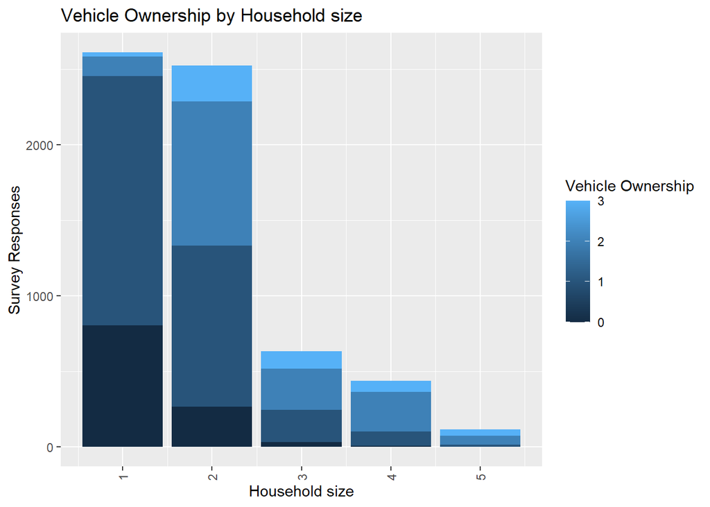

```
##                 Value Std. Error   t value     p-value simp p-value
## explanatory 1.0850573 0.02823457 38.430096 0.000000000       0.0000
## 0|1         0.1701572 0.05364303  3.172027 0.001513787       0.0015
## 1|2         2.7887801 0.06365376 43.811708 0.000000000       0.0000
## 2|3         5.0380862 0.08953261 56.270964 0.000000000       0.0000
```

**Vehicle Ownership by Household size**

|  | *Dependent variable:* |
| --- | --- |
|  | outcome |
| explanatory | 1.085*** |
|  | (0.028) |
| Observations | 6,319 |
| *Note:* | <sup>⋆</sup>p<0.1; <sup>⋆⋆</sup>p<0.05; <sup>⋆⋆⋆</sup>p<0.01 |

#### *4. Number of household licenses*

Original data at a person level (11,940 survey respondents)

|  | Overall (N=11940) |
| --- | --- |
| license |  |
| Missing: Skip logic | 747 (6%) |
| No, does not have a license or permit | 778 (7%) |
| Yes, has a learner’s permit | 120 (1%) |
| Yes, has an intermediate or unrestricted license | 9519 (80%) |
| Missing | 776 (6.5%) |

These categories have been simplified to drivers or non-drivers. Those with a permit are considered to be drivers as they are in the pursuit of a license. Despite this recategorization, there is a large disparity between these groups, with over 10 times as many people reporting that they have a license.

|  | Overall (N=11940) |
| --- | --- |
| license_simp |  |
| Driver | 10415 (87%) |
| Missing | 747 (6%) |
| Non-driver | 778 (7%) |

The person level data of having a license is aggregated to the household level. The following values reflect the number of licenses within each surveyed household (6,319 households).

```
## Frequencies
## person_and_household$hh_driver
## Type: Numeric
##
##               Freq   % Valid   % Valid Cum.   % Total   % Total Cum.
## ----------- ------ --------- -------------- --------- --------------
##           0    289      4.57           4.57      4.57           4.57
##           1   2678     42.38          46.95     42.38          46.95
##           2   2654     42.00          88.95     42.00          88.95
##           3    421      6.66          95.62      6.66          95.62
##           4    236      3.73          99.35      3.73          99.35
##           5     30      0.47          99.83      0.47          99.83
##           6      7      0.11          99.94      0.11          99.94
##           7      3      0.05          99.98      0.05          99.98
##           9      1      0.02         100.00      0.02         100.00
##        <NA>      0                               0.00         100.00
##       Total   6319    100.00         100.00    100.00         100.00
```

Because there are so few households with more than 4 drivers, these categories have been simplified.

```
## Frequencies
## person_and_household$driver_simp
## Type: Numeric
##
##               Freq   % Valid   % Valid Cum.   % Total   % Total Cum.
## ----------- ------ --------- -------------- --------- --------------
##           1    289      4.57           4.57      4.57           4.57
##           2   2678     42.38          46.95     42.38          46.95
##           3   2654     42.00          88.95     42.00          88.95
##           4    421      6.66          95.62      6.66          95.62
##           5    277      4.38         100.00      4.38         100.00
##        <NA>      0                               0.00         100.00
##       Total   6319    100.00         100.00    100.00         100.00
```

Margin of Error

| driver_simp | Percentage_0 | Percentage_1 | Percentage_2 | Percentage_3 | Total_0 | Total_1 | Total_2 | Total_3 | Count_0 | Count_1 | Count_2 | Count_3 | sample_size | MOE_Percent |
| --- | --- | --- | --- | --- | --- | --- | --- | --- | --- | --- | --- | --- | --- | --- |
| 1 | 99.7976806 | 0.1137874 | 0.08853204 | NA | 58372.686 | 66.5554 | 51.7833 | NA | 284 | 4 | 1 | NA | 289 | 4.838235 |
| 2 | 10.9435119 | 77.4493707 | 10.23055251 | 1.376565 | 50793.538 | 359475.7856 | 47484.3871 | 6389.229 | 645 | 1856 | 149 | 28 | 2678 | 1.589391 |
| 3 | 2.4683995 | 17.2870823 | 54.72622450 | 25.518294 | 18192.717 | 127410.0919 | 403345.8723 | 188076.165 | 164 | 1017 | 1186 | 287 | 2654 | 1.596561 |
| 4 | 0.7932645 | 8.5490311 | 33.56844757 | 57.089257 | 1703.912 | 18363.1005 | 72104.1681 | 122626.266 | 15 | 108 | 179 | 119 | 421 | 4.008620 |
| 5 | 0.3462057 | 3.9329136 | 55.90742752 | 39.813453 | 631.130 | 7169.6677 | 101918.7587 | 72579.582 | 3 | 48 | 166 | 60 | 277 | 4.941924 |

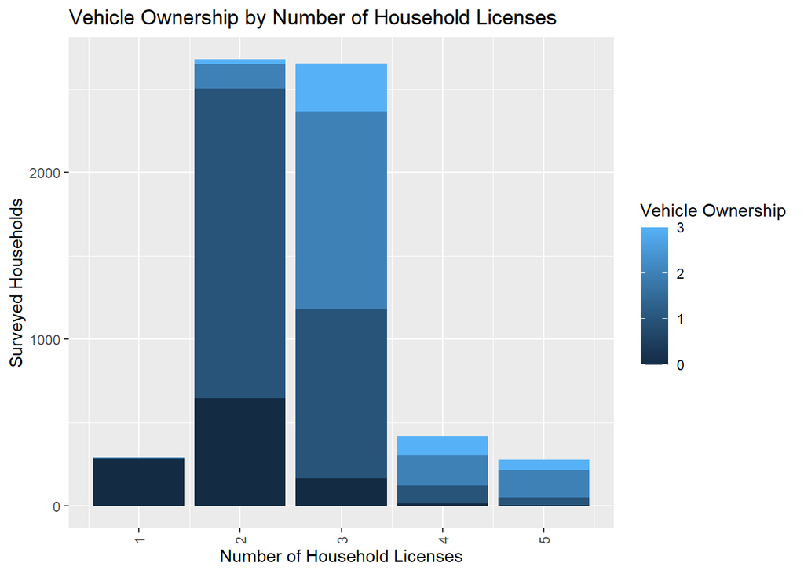

Reference group: 0 licenses in the household

```
##                Value Std. Error  t value       p-value simp p-value
## explanatory 1.610632 0.03623059 44.45504  0.000000e+00            0
## 0|1         2.202101 0.08719917 25.25369 1.031591e-140            0
## 1|2         5.078522 0.10525102 48.25152  0.000000e+00            0
## 2|3         7.469065 0.13074043 57.12896  0.000000e+00            0
```

**Vehicle Ownership by Number of Household Licenses**

|  | *Dependent variable:* |
| --- | --- |
|  | outcome |
| explanatory | 1.611*** |
|  | (0.036) |
| Observations | 6,319 |
| *Note:* | <sup>⋆</sup>p<0.1; <sup>⋆⋆</sup>p<0.05; <sup>⋆⋆⋆</sup>p<0.01 |

In reference to the households with no licensed members, households with more licensed drivers are more likely to own more vehicles. This positive association between number of household licenses and household vehicle ownership is statistically significant.

#### *5. Number of workers*

This variable is defined as number of household members with 1+ jobs.

Original data at a household level

```
## Frequencies
## person_and_household$numworkers
## Type: Factor
##
##               Freq   % Valid   % Valid Cum.   % Total   % Total Cum.
## ----------- ------ --------- -------------- --------- --------------
##           0   1190     18.83          18.83     18.83          18.83
##           1   2920     46.21          65.04     46.21          65.04
##           2   2054     32.51          97.55     32.51          97.55
##           3    131      2.07          99.62      2.07          99.62
##           4     20      0.32          99.94      0.32          99.94
##           5      4      0.06         100.00      0.06         100.00
##        <NA>      0                               0.00         100.00
##       Total   6319    100.00         100.00    100.00         100.00
```

Because there are so few people with more than 4 people, these households have been grouped together into one category for analysis.

|  | Overall (N=6319) |
| --- | --- |
| numworkers_simp |  |
| 1 | 1190 (19%) |
| 2 | 2920 (46%) |
| 3 | 2054 (33%) |
| 4 | 155 (2%) |

| numworkers_simp | Percentage_0 | Percentage_1 | Percentage_2 | Percentage_3 | Total_0 | Total_1 | Total_2 | Total_3 | Count_0 | Count_1 | Count_2 | Count_3 | sample_size | MOE_Percent |
| --- | --- | --- | --- | --- | --- | --- | --- | --- | --- | --- | --- | --- | --- | --- |
| 1 | 15.9871410 | 37.05190 | 32.69776 | 14.26320 | 51933.9266 | 120362.384 | 106218.1 | 46333.74 | 318 | 547 | 245 | 80 | 1190 | 2.384308 |
| 2 | 9.5256602 | 49.00161 | 29.38933 | 12.08340 | 59465.2985 | 305899.543 | 183467.1 | 75432.38 | 622 | 1700 | 469 | 129 | 2920 | 1.522105 |
| 3 | 3.0417116 | 13.43068 | 53.45642 | 30.07118 | 17445.6049 | 77031.079 | 306597.0 | 172471.97 | 167 | 758 | 912 | 217 | 2054 | 1.814829 |
| 4 | 0.6332362 | 6.85487 | 21.34480 | 71.16710 | 849.1526 | 9192.194 | 28622.8 | 95433.15 | 4 | 28 | 55 | 68 | 155 | 6.606479 |

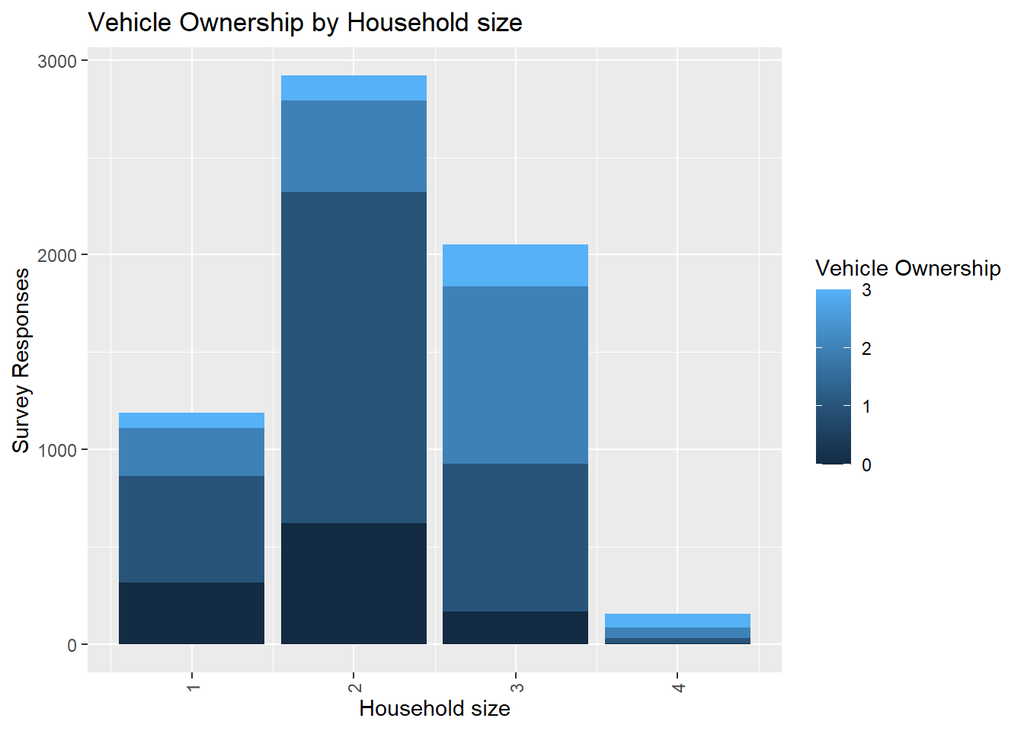

Reference group: 1 person

```
##                 Value Std. Error   t value       p-value simp p-value
## explanatory 0.8095296 0.03330120 24.309324 1.562224e-130       0.0000
## 0|1         0.1137228 0.07441622  1.528199  1.264631e-01       0.1265
## 1|2         2.4717576 0.08145516 30.345008 2.923931e-202       0.0000
## 2|3         4.4057105 0.09578047 45.998005  0.000000e+00       0.0000
```

**Vehicle Ownership by Number of Workers**

|  | *Dependent variable:* |
| --- | --- |
|  | outcome |
| explanatory | 0.810*** |
|  | (0.033) |
| Observations | 6,319 |
| *Note:* | <sup>⋆</sup>p<0.1; <sup>⋆⋆</sup>p<0.05; <sup>⋆⋆⋆</sup>p<0.01 |

In reference to the households with one person, households with more workers are more likely to own more vehicles. This positive association between the number of household workers and household vehicle ownership is statistically significant.

#### *6. Number of Jobs*

Original data at a person level (11,940 survey respondents)

```
## Frequencies
## person$jobs_count
## Type: Character
##
##                              Freq   % Valid   % Valid Cum.   % Total   % Total Cum.
## ------------------------- ------- --------- -------------- --------- --------------
##                    0 jobs      91      0.94           0.94      0.76           0.76
##                     1 job    6799     70.48          71.42     56.94          57.71
##                    2 jobs     554      5.74          77.16      4.64          62.35
##                    3 jobs      87      0.90          78.07      0.73          63.07
##                    4 jobs      16      0.17          78.23      0.13          63.21
##            5 or more jobs      28      0.29          78.52      0.23          63.44
##       Missing: Skip logic    2072     21.48         100.00     17.35          80.80
##                      <NA>    2293                              19.20         100.00
##                     Total   11940    100.00         100.00    100.00         100.00
```

The person level jobs data is aggregated to the household level. The following tables reflect the sum of the jobs held by individuals within each of the surveyed households (6,319).

```
## Frequencies
## person_and_household$hh_jobs
## Type: Numeric
##
##               Freq   % Valid   % Valid Cum.   % Total   % Total Cum.
## ----------- ------ --------- -------------- --------- --------------
##           0   1195     18.91          18.91     18.91          18.91
##           1   2661     42.11          61.02     42.11          61.02
##           2   1947     30.81          91.83     30.81          91.83
##           3    363      5.74          97.58      5.74          97.58
##           4     84      1.33          98.91      1.33          98.91
##           5     44      0.70          99.60      0.70          99.60
##           6     15      0.24          99.84      0.24          99.84
##           7      7      0.11          99.95      0.11          99.95
##          10      2      0.03          99.98      0.03          99.98
##          13      1      0.02         100.00      0.02         100.00
##        <NA>      0                               0.00         100.00
##       Total   6319    100.00         100.00    100.00         100.00
```

##### *Jobs : Worker ratio*

The number of household jobs per worker (sum of household jobs/sum household members with 1+ jobs) was calculated to create a more standardized measurement.

```
##    Min. 1st Qu.  Median    Mean 3rd Qu.    Max.
##  0.0000  0.5000  0.5000  0.5195  0.6667  3.3333
```

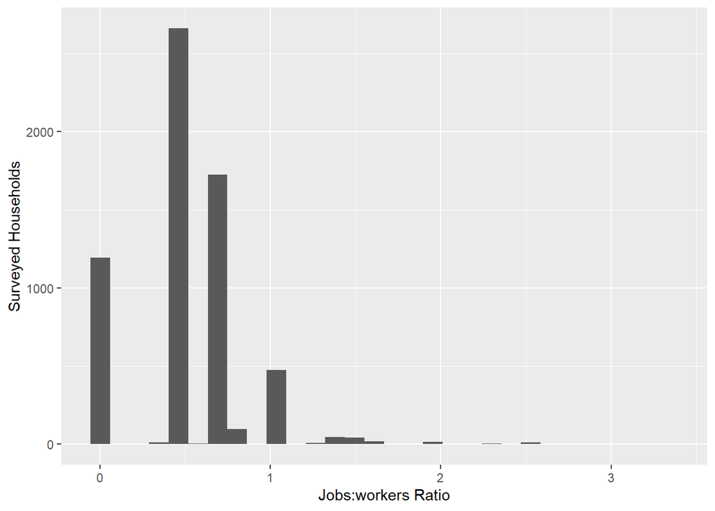

```
##                  Value Std. Error   t value       p-value simp p-value
## explanatory  0.8747133 0.07357472  11.88878  1.353761e-32            0
## 0|1         -1.1163914 0.04822413 -23.15006 1.451715e-118            0
## 1|2          1.1128665 0.04790333  23.23151 2.188080e-119            0
## 2|3          2.9577527 0.06332095  46.71049  0.000000e+00            0
```

**Vehicle Ownership by jobs:workers ratio**

|  | *Dependent variable:* |
| --- | --- |
|  | outcome |
| explanatory | 0.875*** |
|  | (0.074) |
| Observations | 6,319 |
| *Note:* | <sup>⋆</sup>p<0.1; <sup>⋆⋆</sup>p<0.05; <sup>⋆⋆⋆</sup>p<0.01 |

When there are more jobs/workers within a household, these households are more likely to own more vehicles. This positive association between the number of jobs per household worker and household vehicle ownership is statistically significant.

#### *7. Educational attainment*

Original data at a person level (11,940 survey respondents)

|  | Overall (N=11940) |
| --- | --- |
| education |  |
| Associates degree | 606 (5%) |
| Bachelor degree | 4182 (35%) |
| Graduate/post-graduate degree | 3312 (28%) |
| High school graduate | 642 (5%) |
| Less than high school | 126 (1%) |
| Missing: Skip logic | 801 (7%) |
| Some college | 1154 (10%) |
| Vocational/technical training | 268 (2%) |
| Missing | 849 (7.1%) |

The person level education data is aggregated to the household level. The following tables reflect the lowest and highest educational attainment of the individuals within each of the surveyed households (6,319).

```
## Frequencies
## person_and_household$education_min
## Type: Character
##
##                                       Freq   % Valid   % Valid Cum.   % Total   % Total Cum.
## ----------------------------------- ------ --------- -------------- --------- --------------
##                   Associates degree    399      6.31           6.31      6.31           6.31
##                     Bachelor degree   2727     43.16          49.47     43.16          49.47
##       Graduate/post-graduate degree   1518     24.02          73.49     24.02          73.49
##                High school graduate    507      8.02          81.52      8.02          81.52
##               Less than high school    114      1.80          83.32      1.80          83.32
##                        Some college    836     13.23          96.55     13.23          96.55
##       Vocational/technical training    218      3.45         100.00      3.45         100.00
##                                <NA>      0                               0.00         100.00
##                               Total   6319    100.00         100.00    100.00         100.00
```

```
## Frequencies
## person_and_household$education_max
## Type: Character
##
##                                       Freq   % Valid   % Valid Cum.   % Total   % Total Cum.
## ----------------------------------- ------ --------- -------------- --------- --------------
##                   Associates degree    337      5.33           5.33      5.33           5.33
##                     Bachelor degree   2495     39.48          44.82     39.48          44.82
##       Graduate/post-graduate degree   2593     41.03          85.85     41.03          85.85
##                High school graduate    187      2.96          88.81      2.96          88.81
##               Less than high school     20      0.32          89.13      0.32          89.13
##                        Some college    593      9.38          98.51      9.38          98.51
##       Vocational/technical training     94      1.49         100.00      1.49         100.00
##                                <NA>      0                               0.00         100.00
##                               Total   6319    100.00         100.00    100.00         100.00
```

These education attainment categories have been simplified into the following 4 categories:

- high school or less
- vocational, associates, less than 4 years of college
- bachelor degree
- post-graduate

```
## Frequencies
## person_and_household$hh_edu_min_simp
## Type: Character
##
##                          Freq   % Valid   % Valid Cum.   % Total   % Total Cum.
## ---------------------- ------ --------- -------------- --------- --------------
##        Bachelor degree   2727     43.16          43.16     43.16          43.16
##            high school    621      9.83          52.98      9.83          52.98
##          post-graduate   1518     24.02          77.01     24.02          77.01
##       specialized, <4y   1453     22.99         100.00     22.99         100.00
##                   <NA>      0                               0.00         100.00
##                  Total   6319    100.00         100.00    100.00         100.00
```

```
## Frequencies
## person_and_household$hh_edu_max_simp
## Type: Character
##
##                          Freq   % Valid   % Valid Cum.   % Total   % Total Cum.
## ---------------------- ------ --------- -------------- --------- --------------
##        Bachelor degree   2495     39.48          39.48     39.48          39.48
##            High school    207      3.28          42.76      3.28          42.76
##          Post-graduate   2593     41.03          83.79     41.03          83.79
##       Specialized, <4y   1024     16.21         100.00     16.21         100.00
##                   <NA>      0                               0.00         100.00
##                  Total   6319    100.00         100.00    100.00         100.00
```

##### *Household education minimum*

Margin of Error

| hh_edu_min_simp | Percentage_0 | Percentage_1 | Percentage_2 | Percentage_3 | Total_0 | Total_1 | Total_2 | Total_3 | Count_0 | Count_1 | Count_2 | Count_3 | sample_size | MOE_Percent |
| --- | --- | --- | --- | --- | --- | --- | --- | --- | --- | --- | --- | --- | --- | --- |
| Bachelor degree | 6.794764 | 34.20082 | 45.34123 | 13.66319 | 34167.62 | 171979.57 | 227999.38 | 68705.66 | 481 | 1394 | 716 | 136 | 2727 | 1.575046 |
| high school | 7.255363 | 20.54531 | 36.82640 | 35.37293 | 25151.04 | 71221.23 | 127660.35 | 122621.84 | 114 | 194 | 203 | 110 | 621 | 3.300579 |
| post-graduate | 11.219221 | 42.85882 | 33.26802 | 12.65395 | 29920.83 | 114301.27 | 88723.33 | 33747.13 | 256 | 862 | 342 | 58 | 1518 | 2.111057 |
| specialized, <4y | 7.483865 | 28.67105 | 33.39559 | 30.44949 | 40454.49 | 154983.13 | 180521.91 | 164596.62 | 260 | 583 | 420 | 190 | 1453 | 2.157760 |

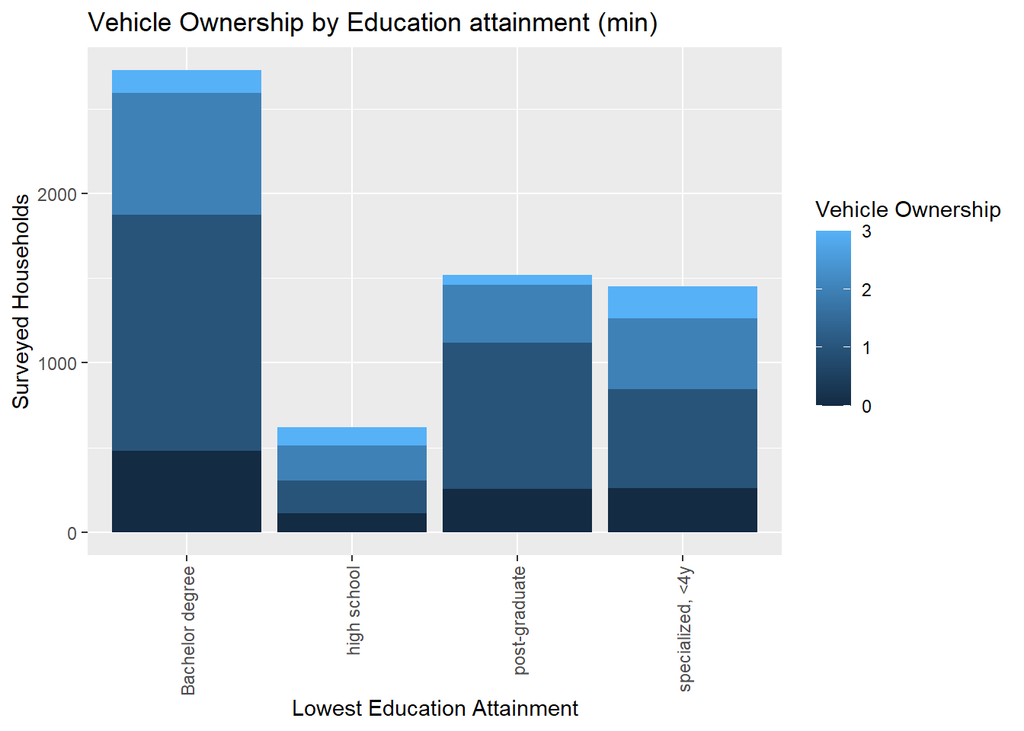

Reference group: Bachelor degree

```
##                                  Value Std. Error    t value       p-value
## explanatoryhigh school       0.6943598 0.08640557   8.036054  9.277762e-16
## explanatorypost-graduate    -0.1150831 0.05865768  -1.961945  4.976887e-02
## explanatoryspecialized, <4y  0.3847483 0.06164529   6.241326  4.338780e-10
## 0|1                         -1.4480497 0.04188894 -34.568782 7.443668e-262
## 1|2                          0.7653755 0.03776222  20.268287  2.450410e-91
## 2|3                          2.6178768 0.05501078  47.588428  0.000000e+00
##                             simp p-value
## explanatoryhigh school            0.0000
## explanatorypost-graduate          0.0498
## explanatoryspecialized, <4y       0.0000
## 0|1                               0.0000
## 1|2                               0.0000
## 2|3                               0.0000
```

**Vehicle Ownership by Lowest educational attainment**

|  | *Dependent variable:* |
| --- | --- |
|  | outcome |
| explanatoryhigh school | 0.694*** |
|  | (0.086) |
| explanatorypost-graduate | -0.115** |
|  | (0.059) |
| explanatoryspecialized, < 4y | 0.385*** |
|  | (0.062) |
| Observations | 6,319 |
| *Note:* | <sup>⋆</sup>p<0.1; <sup>⋆⋆</sup>p<0.05; <sup>⋆⋆⋆</sup>p<0.01 |

In reference to the households with a bachelor degree as the lowest educational attainment, households with more education (post-graduate) are less likely to own more vehicles, while those with less education are more likely to own more vehicles. This negative association between educational attainment (min) and household vehicle ownership is statistically significant.

##### *Household education maximum*

Margin of Error

| hh_edu_max_simp | Percentage_0 | Percentage_1 | Percentage_2 | Percentage_3 | Total_0 | Total_1 | Total_2 | Total_3 | Count_0 | Count_1 | Count_2 | Count_3 | sample_size | MOE_Percent |
| --- | --- | --- | --- | --- | --- | --- | --- | --- | --- | --- | --- | --- | --- | --- |
| Bachelor degree | 5.734550 | 33.70894 | 33.54816 | 27.00835 | 33313.51 | 195824.1 | 194890.08 | 156898.626 | 461 | 1253 | 601 | 180 | 2495 | 1.646647 |
| High school | 20.151476 | 38.47451 | 29.70959 | 11.66442 | 16106.77 | 30752.1 | 23746.43 | 9323.194 | 74 | 78 | 43 | 12 | 207 | 5.716770 |
| Post-graduate | 5.567242 | 24.64086 | 47.91840 | 21.87351 | 34016.90 | 150560.3 | 292790.41 | 133651.236 | 328 | 1258 | 816 | 191 | 2593 | 1.615231 |
| Specialized, <4y | 12.018446 | 35.16631 | 29.48387 | 23.33137 | 46256.81 | 135348.7 | 113478.05 | 89798.186 | 248 | 444 | 221 | 111 | 1024 | 2.570312 |

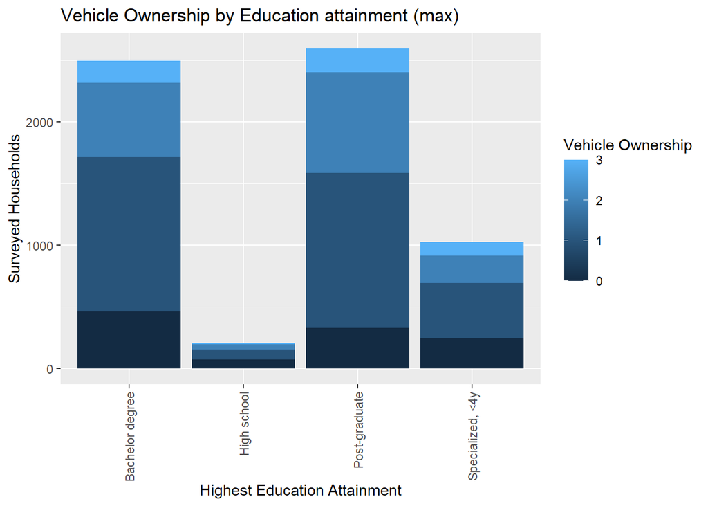

Reference group: Bachelor degree

```
##                                   Value Std. Error    t value       p-value
## explanatoryHigh school      -0.60844237 0.14186260  -4.288955  1.795154e-05
## explanatoryPost-graduate     0.32388254 0.05198363   6.230472  4.650333e-10
## explanatorySpecialized, <4y -0.07264983 0.07126180  -1.019478  3.079761e-01
## 0|1                         -1.45314627 0.04349957 -33.405990 1.122147e-244
## 1|2                          0.76098317 0.03974401  19.147115  1.022987e-81
## 2|3                          2.59091658 0.05597496  46.287062  0.000000e+00
##                             simp p-value
## explanatoryHigh school             0.000
## explanatoryPost-graduate           0.000
## explanatorySpecialized, <4y        0.308
## 0|1                                0.000
## 1|2                                0.000
## 2|3                                0.000
```

**Vehicle Ownership by Highest educational attainment**

|  | *Dependent variable:* |
| --- | --- |
|  | outcome |
| explanatoryHigh school | -0.608*** |
|  | (0.142) |
| explanatoryPost-graduate | 0.324*** |
|  | (0.052) |
| explanatorySpecialized, < 4y | -0.073 |
|  | (0.071) |
| Observations | 6,319 |
| *Note:* | <sup>⋆</sup>p<0.1; <sup>⋆⋆</sup>p<0.05; <sup>⋆⋆⋆</sup>p<0.01 |

In reference to the households with a bachelor degree as the highest educational attainment, households with more education (post-graduate) are more likely to own more vehicles, while those with high school or less are less likely to own more vehicles. This positive association between educational attainment (max) and household vehicle ownership is statistically significant.  
The relationship between households with specialized/vocational/less than 4 years of college and a bachelor degree is not significant.

#### *8. Race*

The household travel survey asked participants about the race of adults in each household, with no children in households assigned to any racial group.  
Original data at a person level (11,940 survey respondents).

|  | Overall (N=11940) |
| --- | --- |
| race_category |  |
| African American | 257 (2%) |
| Asian | 1513 (13%) |
| Child | 1650 (14%) |
| Hispanic | 380 (3%) |
| Missing | 690 (6%) |
| Other | 443 (4%) |
| White Only | 7007 (59%) |

The person level race data is aggregated to the household level (6,319) based on the following logic:

1. Households were grouped into single racial groups alone based on the identified race of the individual members (i.e. African American alone, Asian alone, Hispanic alone, etc.), as well as a category for households with members of different races

   |  | Overall (N=6319) |
   | --- | --- |
   | hh_race_category |  |
   | African American | 185 (3%) |
   | Asian | 1024 (16%) |
   | Hispanic | 282 (4%) |
   | Missing | 427 (7%) |
   | Other | 400 (6%) |
   | White Only | 4001 (63%) |

2. Other than Asian and Non-Hispanic White, the groups were too small to report, and were therefore combined together into categories large enough to achieve statistically valid sample sizes. Survey participants could choose not to select any choice for race; households with any adults missing race were assigned to a Missing group. The “Missing/Other” group includes households categorized as “Missing” or “Other.”

Three groups are shown in the analysis below:

- A composite of households where all adults are African American, Hispanic, or Native American, and households with non-White adults of multiple races
- Households where all adults are Asian alone
- Households where all adults are Non-Hispanic White alone

##### *White Only, Asian, and other POC households*

| hh_race_3 | Percentage_0 | Percentage_1 | Percentage_2 | Percentage_3 | Total_0 | Total_1 | Total_2 | Total_3 | Count_0 | Count_1 | Count_2 | Count_3 | sample_size | MOE_Percent |
| --- | --- | --- | --- | --- | --- | --- | --- | --- | --- | --- | --- | --- | --- | --- |
| Asian | 10.901398 | 33.87965 | 42.60974 | 12.60921 | 21070.38 | 65483.07 | 82356.72 | 24371.27 | 195 | 499 | 275 | 55 | 1024 | 2.570312 |
| Missing/Other | 5.480810 | 34.71955 | 36.13132 | 23.66832 | 25865.91 | 163854.03 | 170516.69 | 111699.34 | 145 | 379 | 227 | 76 | 827 | 2.860113 |
| People of Color | 12.503948 | 40.72706 | 31.67759 | 15.09140 | 28982.44 | 94399.75 | 73424.31 | 34979.81 | 96 | 218 | 120 | 33 | 467 | 3.806076 |
| White Only | 7.078003 | 24.84343 | 39.30327 | 28.77530 | 53775.25 | 188748.36 | 298607.25 | 218620.83 | 675 | 1937 | 1059 | 330 | 4001 | 1.300324 |

Reference group: White Only

```
##                                  Value Std. Error     t value      p-value
## explanatoryPeople of Color -0.15042878 0.09182533  -1.6382058 1.013788e-01
## explanatoryAsian           -0.14693091 0.06502539  -2.2595928 2.384654e-02
## explanatoryMissing/Other    0.04710565 0.07152822   0.6585603 5.101782e-01
## 0|1                        -1.57518349 0.03773342 -41.7450504 0.000000e+00
## 1|2                         0.61620153 0.03180728  19.3729741 1.304973e-83
## 2|3                         2.44012840 0.05000267  48.7999598 0.000000e+00
##                            simp p-value
## explanatoryPeople of Color       0.1014
## explanatoryAsian                 0.0238
## explanatoryMissing/Other         0.5102
## 0|1                              0.0000
## 1|2                              0.0000
## 2|3                              0.0000
```

**Vehicle Ownership by Race**

|  | *Dependent variable:* |
| --- | --- |
|  | outcome |
| explanatoryPeople of Color | -0.150 |
|  | (0.092) |
| explanatoryAsian | -0.147** |
|  | (0.065) |
| explanatoryMissing/Other | 0.047 |
|  | (0.072) |
| Observations | 6,319 |
| *Note:* | <sup>⋆</sup>p<0.1; <sup>⋆⋆</sup>p<0.05; <sup>⋆⋆⋆</sup>p<0.01 |

The relationship between race and household vehicle ownership is statistically significant for Asian households. POC households show a similar trend - owning fewer vehicles than white households - but the relationship is not significant. This is likely because of the small sample size of POC households, excluding Asian households (less than 10% of the sample: 467/6,319). This indicates that the White Only and POC household analysis is largely based on Asian households (~16%: 1,024/6,319).

##### *Alternative: White Only and POC households*

Because of the small numbers of respondents identifying as non-white, these groups have been grouped together as “POC” - including households with individuals who identified as “African American,” “Asian”, and “Hispanic.”

|  | Overall (N=6319) |
| --- | --- |
| hh_race_2 |  |
| Missing/Other | 827 (13%) |
| People of Color | 1491 (24%) |
| White Only | 4001 (63%) |

| hh_race_2 | Percentage_0 | Percentage_1 | Percentage_2 | Percentage_3 | Total_0 | Total_1 | Total_2 | Total_3 | Count_0 | Count_1 | Count_2 | Count_3 | sample_size | MOE_Percent |
| --- | --- | --- | --- | --- | --- | --- | --- | --- | --- | --- | --- | --- | --- | --- |
| Missing/Other | 5.480810 | 34.71955 | 36.13132 | 23.66832 | 25865.91 | 163854.0 | 170516.7 | 111699.34 | 145 | 379 | 227 | 76 | 827 | 2.860113 |
| People of Color | 11.775257 | 37.61349 | 36.64852 | 13.96273 | 50052.82 | 159882.8 | 155781.0 | 59351.07 | 291 | 717 | 395 | 88 | 1491 | 2.130086 |
| White Only | 7.078003 | 24.84343 | 39.30327 | 28.77530 | 53775.25 | 188748.4 | 298607.2 | 218620.83 | 675 | 1937 | 1059 | 330 | 4001 | 1.300324 |

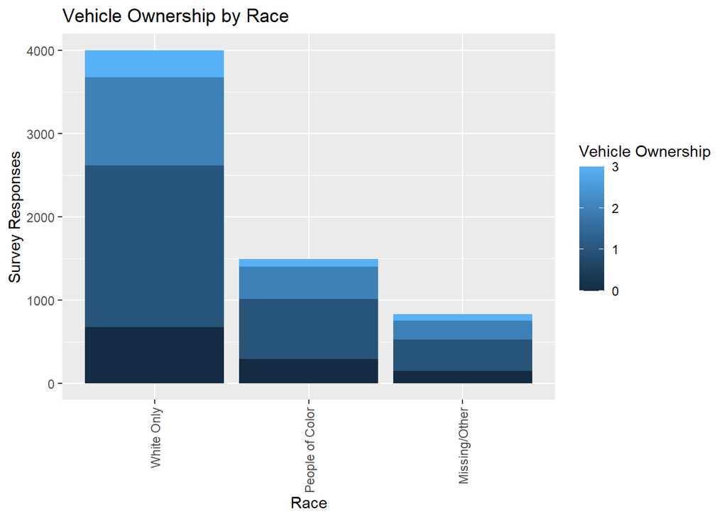

Reference group: White Only

```
##                                  Value Std. Error     t value      p-value
## explanatoryPeople of Color -0.14800765 0.05652203  -2.6185836 8.829566e-03
## explanatoryMissing/Other    0.04711776 0.07152829   0.6587289 5.100699e-01
## 0|1                        -1.57522662 0.03773383 -41.7457434 0.000000e+00
## 1|2                         0.61617300 0.03180727  19.3720818 1.327789e-83
## 2|3                         2.44010829 0.05000266  48.7995649 0.000000e+00
##                            simp p-value
## explanatoryPeople of Color       0.0088
## explanatoryMissing/Other         0.5101
## 0|1                              0.0000
## 1|2                              0.0000
## 2|3                              0.0000
```

**Vehicle Ownership by Race**

|  | *Dependent variable:* |
| --- | --- |
|  | outcome |
| explanatoryPeople of Color | -0.148*** |
|  | (0.057) |
| explanatoryMissing/Other | 0.047 |
|  | (0.072) |
| Observations | 6,319 |
| *Note:* | <sup>⋆</sup>p<0.1; <sup>⋆⋆</sup>p<0.05; <sup>⋆⋆⋆</sup>p<0.01 |

The relationship between race and household vehicle ownership is statistically significant with POC households owning fewer vehicles.

#### *9. Housing*

This category can be analyzed at two different levels:

- housing tenure (rent vs. own)
- residential type

##### *Housing tenure*

|  | Overall (N=6319) |
| --- | --- |
| rent_own |  |
| Other | 71 (1%) |
| Own/paying mortgage | 3011 (48%) |
| Prefer not to answer | 68 (1%) |
| Provided by job or military | 21 (0%) |
| Rent | 3148 (50%) |

Because the majority of respondents identify as renters or owners, the other categories with fewer responses were grouped together.

|  | Overall (N=6319) |
| --- | --- |
| rent_own_simp |  |
| Own/paying mortgage | 3011 (48%) |
| Rent | 3148 (50%) |
| Other | 160 (3%) |

| rent_own_simp | Percentage_0 | Percentage_1 | Percentage_2 | Percentage_3 | Total_0 | Total_1 | Total_2 | Total_3 | Count_0 | Count_1 | Count_2 | Count_3 | sample_size | MOE_Percent |
| --- | --- | --- | --- | --- | --- | --- | --- | --- | --- | --- | --- | --- | --- | --- |
| Other | 7.318935 | 42.72362 | 39.72540 | 10.232039 | 6352.305 | 37081.0 | 34478.76 | 8880.668 | 29 | 66 | 52 | 13 | 160 | 6.502433 |
| Own/paying mortgage | 1.273685 | 21.79471 | 43.90040 | 33.031205 | 13283.330 | 227298.1 | 457839.60 | 344484.166 | 149 | 1274 | 1168 | 420 | 3011 | 1.498927 |
| Rent | 20.881661 | 47.07382 | 25.15601 | 6.888511 | 110058.348 | 248106.1 | 132586.60 | 36306.408 | 933 | 1693 | 461 | 61 | 3148 | 1.465948 |

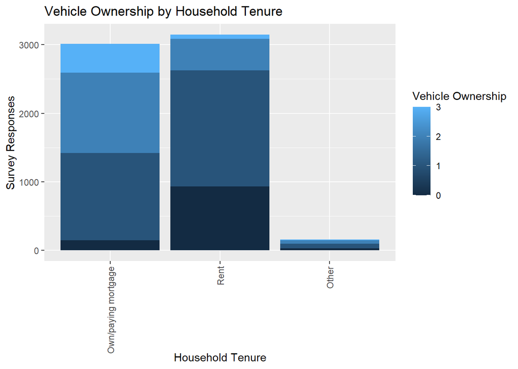

Reference group: Own/paying mortgage

```
##                       Value Std. Error    t value       p-value simp p-value
## explanatoryRent  -1.8294667 0.05436545 -33.651273 2.987023e-248            0
## explanatoryOther -0.7179186 0.15915860  -4.510712  6.461042e-06            0
## 0|1              -2.7238992 0.05206467 -52.317608  0.000000e+00            0
## 1|2              -0.1490572 0.03550110  -4.198664  2.684942e-05            0
## 2|3               1.8552072 0.04981538  37.241656 1.446079e-303            0
```

**Vehicle Ownership by Household Tenure**

|  | *Dependent variable:* |
| --- | --- |
|  | outcome |
| explanatoryRent | -1.829*** |
|  | (0.054) |
| explanatoryOther | -0.718*** |
|  | (0.159) |
| Observations | 6,319 |
| *Note:* | <sup>⋆</sup>p<0.1; <sup>⋆⋆</sup>p<0.05; <sup>⋆⋆⋆</sup>p<0.01 |

The relationship between household tenure and household vehicle ownership is statistically significant, with renting individuals reporting that they are part of households that own fewer vehicles.

##### *Housing type*

|  | Overall (N=6319) |
| --- | --- |
| res_type |  |
| Building with 3 or fewer apartments/condos | 195 (3%) |
| Building with 4 or more apartments/condos | 3390 (54%) |
| Dorm or institutional housing | 24 (0%) |
| Mobile home/trailer | 39 (1%) |
| Other (including boat, RV, van, etc.) | 17 (0%) |
| Single-family house (detached house) | 2120 (34%) |
| Townhouse (attached house) | 534 (8%) |

Because the majority of respondents identify as living in apartment buildings or single-family detached houses, the survey responses have been simplified and recategorized.

|  | Overall (N=6319) |
| --- | --- |
| restype_simp |  |
| Apartment/condo | 3585 (57%) |
| Other | 80 (1%) |
| Single-family | 2120 (34%) |
| Townhouse | 534 (8%) |

| restype_simp | Percentage_0 | Percentage_1 | Percentage_2 | Percentage_3 | Total_0 | Total_1 | Total_2 | Total_3 | Count_0 | Count_1 | Count_2 | Count_3 | sample_size | MOE_Percent |
| --- | --- | --- | --- | --- | --- | --- | --- | --- | --- | --- | --- | --- | --- | --- |
| Apartment/condo | 21.870412 | 55.82154 | 21.32350 | 0.9845535 | 107501.116 | 274383.38 | 104812.830 | 4839.442 | 1000 | 2043 | 500 | 42 | 3585 | 1.373698 |
| Other | 5.805563 | 44.04021 | 18.48334 | 31.6708857 | 2091.389 | 15864.99 | 6658.415 | 11409.081 | 20 | 39 | 15 | 6 | 80 | 9.195830 |
| Single-family | 1.741326 | 17.60522 | 45.43883 | 35.2146264 | 17527.974 | 177211.92 | 457381.597 | 354466.039 | 57 | 650 | 995 | 418 | 2120 | 1.786356 |
| Townhouse | 2.098983 | 36.72289 | 45.71682 | 15.4613076 | 2573.504 | 45024.91 | 56052.127 | 18956.680 | 34 | 301 | 171 | 28 | 534 | 3.559306 |

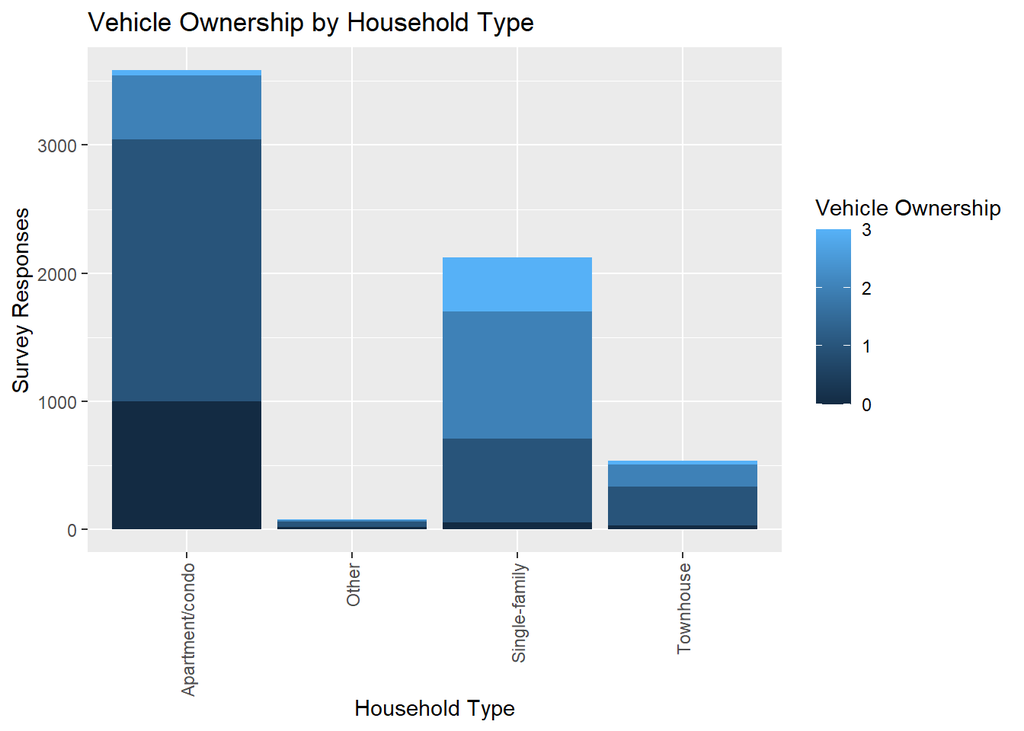

Reference group: Apartment/condo

```
##                               Value Std. Error    t value       p-value
## explanatoryOther          0.4782136 0.23291379   2.053179  4.005526e-02
## explanatorySingle-family  2.5100429 0.06177435  40.632445  0.000000e+00
## explanatoryTownhouse      1.3145898 0.08996581  14.612104  2.351416e-48
## 0|1                      -0.9677376 0.03638624 -26.596249 7.501199e-156
## 1|2                       1.7706405 0.04415778  40.098043  0.000000e+00
## 2|3                       3.9819960 0.06593185  60.395632  0.000000e+00
##                          simp p-value
## explanatoryOther               0.0401
## explanatorySingle-family       0.0000
## explanatoryTownhouse           0.0000
## 0|1                            0.0000
## 1|2                            0.0000
## 2|3                            0.0000
```

**Vehicle Ownership by Household Type**

|  | *Dependent variable:* |
| --- | --- |
|  | outcome |
| explanatoryOther | 0.478** |
|  | (0.233) |
| explanatorySingle-family | 2.510*** |
|  | (0.062) |
| explanatoryTownhouse | 1.315*** |
|  | (0.090) |
| Observations | 6,319 |
| *Note:* | <sup>⋆</sup>p<0.1; <sup>⋆⋆</sup>p<0.05; <sup>⋆⋆⋆</sup>p<0.01 |

The relationship between household type and household vehicle ownership is statistically significant, with single-family (detached) households reporting highest vehicle ownership. Households in townhomes (attached) report higher vehicle ownership than those in apartments or condos, but lower vehicle ownership than those in single-family houses.

#### *10. Housing location*

This measurement will analyze housing location in relation to regional growth centers (RGCs). According to PSRC’s VISION 2050 planning process: “The region has designated 29 regional growth centers. These are locations of the region’s most significant business, governmental, and cultural facilities and are planning for growth.” More information is available at https://www.psrc.org/centers.

```
## Frequencies
## person_and_household$final_home_rgcnum
## Type: Character
##
##                                         Freq   % Valid   % Valid Cum.   % Total   % Total Cum.
## ------------------------------------- ------ --------- -------------- --------- --------------
##                                Auburn      4      0.06           0.06      0.06           0.06
##                     Bellevue Downtown      9      0.14           0.21      0.14           0.21
##                   Bothell Canyon Park     10      0.16           0.36      0.16           0.36
##                             Bremerton      7      0.11           0.47      0.11           0.47
##                                Burien     10      0.16           0.63      0.16           0.63
##                               Everett     20      0.32           0.95      0.32           0.95
##                           Federal Way      3      0.05           1.00      0.05           1.00
##                              Issaquah      3      0.05           1.04      0.05           1.04
##                   Kirkland Totem Lake     13      0.21           1.25      0.21           1.25
##                              Lakewood      7      0.11           1.36      0.11           1.36
##                              Lynnwood      8      0.13           1.49      0.13           1.49
##                               Not RCG   4178     66.12          67.61     66.12          67.61
##                     Puyallup Downtown      4      0.06          67.67      0.06          67.67
##                   Puyallup South Hill     14      0.22          67.89      0.22          67.89
##                      Redmond Downtown    180      2.85          70.74      2.85          70.74
##                      Redmond Overlake     18      0.28          71.02      0.28          71.02
##                                Renton     12      0.19          71.21      0.19          71.21
##                                SeaTac      8      0.13          71.34      0.13          71.34
##                      Seattle Downtown    545      8.62          79.97      8.62          79.97
##       Seattle First Hill/Capitol Hill    530      8.39          88.35      8.39          88.35
##                     Seattle Northgate    111      1.76          90.11      1.76          90.11
##              Seattle South Lake Union    113      1.79          91.90      1.79          91.90
##          Seattle University Community    319      5.05          96.95      5.05          96.95
##                        Seattle Uptown    132      2.09          99.03      2.09          99.03
##                            Silverdale      3      0.05          99.08      0.05          99.08
##                       Tacoma Downtown     36      0.57          99.65      0.57          99.65
##                           Tacoma Mall      6      0.09          99.75      0.09          99.75
##                               Tukwila      2      0.03          99.78      0.03          99.78
##                      University Place     14      0.22         100.00      0.22         100.00
##                                  <NA>      0                               0.00         100.00
##                                 Total   6319    100.00         100.00    100.00         100.00
```

TO simplify analysis, the 29 RGCs are categorized together.

|  | Overall (N=6319) |
| --- | --- |
| RGC_binary |  |
| Not RGC | 4178 (66.1%) |
| RGC | 2141 (33.9%) |

| RGC_binary | Percentage_0 | Percentage_1 | Percentage_2 | Percentage_3 | Total_0 | Total_1 | Total_2 | Total_3 | Count_0 | Count_1 | Count_2 | Count_3 | sample_size | MOE_Percent |
| --- | --- | --- | --- | --- | --- | --- | --- | --- | --- | --- | --- | --- | --- | --- |
| Not RGC | 4.820107 | 29.44523 | 39.58052 | 26.15414 | 70960.61 | 433486.66 | 582696.18 | 385035.910 | 335 | 1975 | 1411 | 457 | 4178 | 1.272482 |
| RGC | 31.820690 | 42.80000 | 22.86797 | 2.51134 | 58733.37 | 78998.55 | 42208.79 | 4635.332 | 776 | 1058 | 270 | 37 | 2141 | 1.777574 |

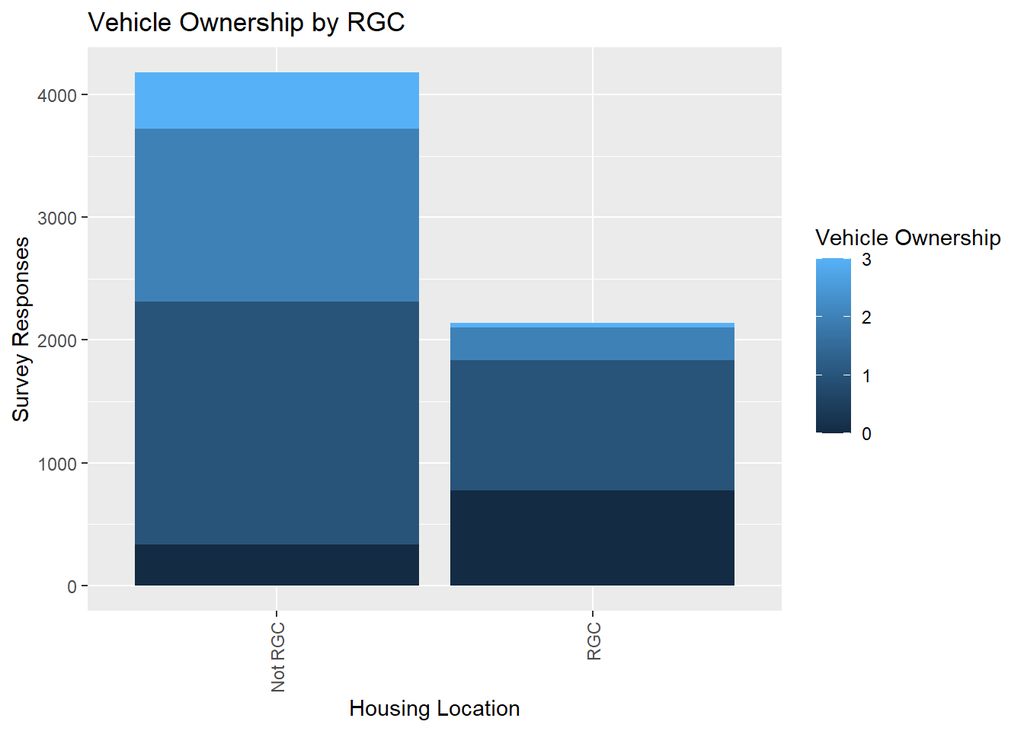

Reference group: Not RGC

```
##                     Value Std. Error    t value       p-value simp p-value
## explanatoryRGC -1.7305428 0.05654716 -30.603532 1.098423e-205            0
## 0|1            -2.3410640 0.04627782 -50.587171  0.000000e+00            0
## 1|2             0.1878121 0.03040031   6.177966  6.493273e-10            0
## 2|3             2.1147563 0.04809758  43.968041  0.000000e+00            0
```

**Vehicle Ownership by RGC**

|  | *Dependent variable:* |
| --- | --- |
|  | outcome |
| explanatoryRGC | -1.731*** |
|  | (0.057) |
| Observations | 6,319 |
| *Note:* | <sup>⋆</sup>p<0.1; <sup>⋆⋆</sup>p<0.05; <sup>⋆⋆⋆</sup>p<0.01 |

Households located in RGCs report lower vehicle ownership than those living outside of RGCs. This is statistically significant.

#### *11 Commute patterns*

There are 4 commute-related variables. The first three are at the person level and the last is at the household-level:

- Distance (mi) by automobile
- Time (min) by automobile
- Commute frequency (days/week)
- Number of household commute trips per week

##### *Commute Distance*

Original data at a person level (11,940 survey respondents)

```
##    Min. 1st Qu.  Median    Mean 3rd Qu.    Max.    NA's
##   0.002   1.859   5.043   9.368  11.564 823.767    8650
```

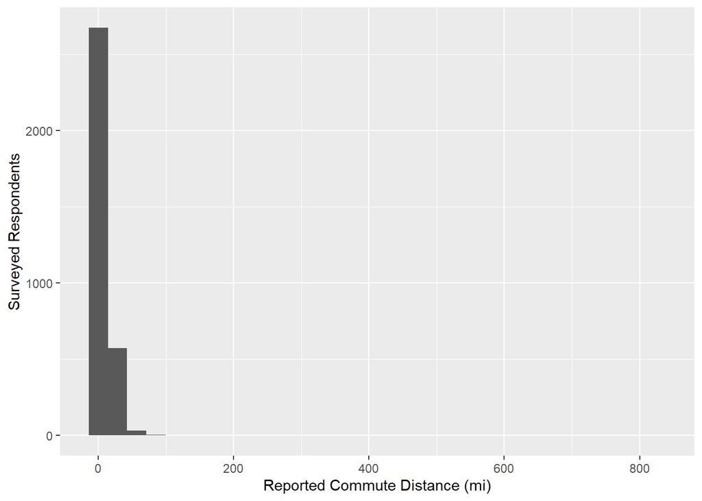

These statistics show outliers within the dataset. **These outliers have not yet been removed.**  
The person level commute distance data is aggregated to the household level (6,319):

- the average commute distance (mi) of the household individuals
- the total commute distance (mi) of the household individuals

###### *Commute distance (average)*

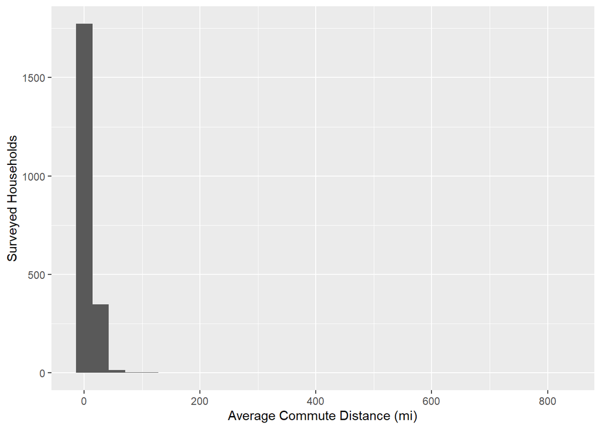

```
##                   Value  Std. Error    t value       p-value simp p-value
## explanatory  0.02065495 0.003799546   5.436162  5.444040e-08            0
## 0|1         -1.42231845 0.064155694 -22.169793 6.721894e-109            0
## 1|2          0.78756154 0.057650474  13.660972  1.736492e-42            0
## 2|3          2.56983141 0.087589300  29.339559 3.247374e-189            0
```

**Vehicle Ownership by Average Commute Distance**

|  | *Dependent variable:* |
| --- | --- |
|  | outcome |
| explanatory | 0.021*** |
|  | (0.004) |
| Observations | 2,145 |
| *Note:* | <sup>⋆</sup>p<0.1; <sup>⋆⋆</sup>p<0.05; <sup>⋆⋆⋆</sup>p<0.01 |

There are fewer observations because of the 4,174 NA values - a result of using the `mean()`.

###### *Commute distance (total)*

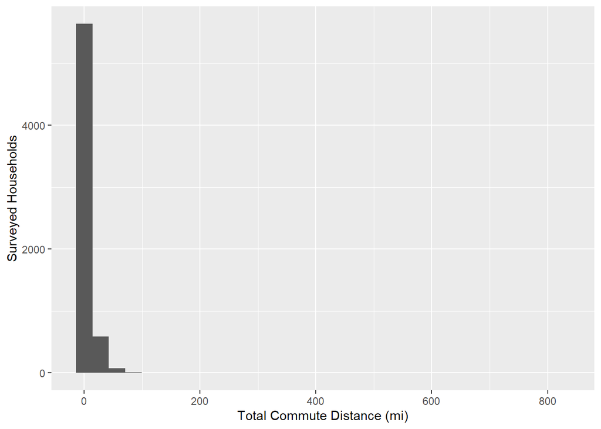

```
##                   Value  Std. Error   t value       p-value simp p-value
## explanatory  0.02193288 0.002165052  10.13042  4.049090e-24            0
## 0|1         -1.46613397 0.033897497 -43.25198  0.000000e+00            0
## 1|2          0.75341116 0.028739673  26.21502 1.791568e-151            0
## 2|3          2.61033330 0.049585625  52.64294  0.000000e+00            0
```

**Vehicle Ownership by Total Commute Distance**

|  | *Dependent variable:* |
| --- | --- |
|  | outcome |
| explanatory | 0.022*** |
|  | (0.002) |
| Observations | 6,319 |
| *Note:* | <sup>⋆</sup>p<0.1; <sup>⋆⋆</sup>p<0.05; <sup>⋆⋆⋆</sup>p<0.01 |

Both average household commute distance and the total household commute distance are positively associated with household vehicle ownership. Although the coefficients are small, these variables are statistically significant.

##### *Commute Time*

Original data at a person level (11,940 survey respondents)

```
##    Min. 1st Qu.  Median    Mean 3rd Qu.    Max.    NA's
##   0.000   8.721  16.983  22.002  29.346 837.050    8650
```

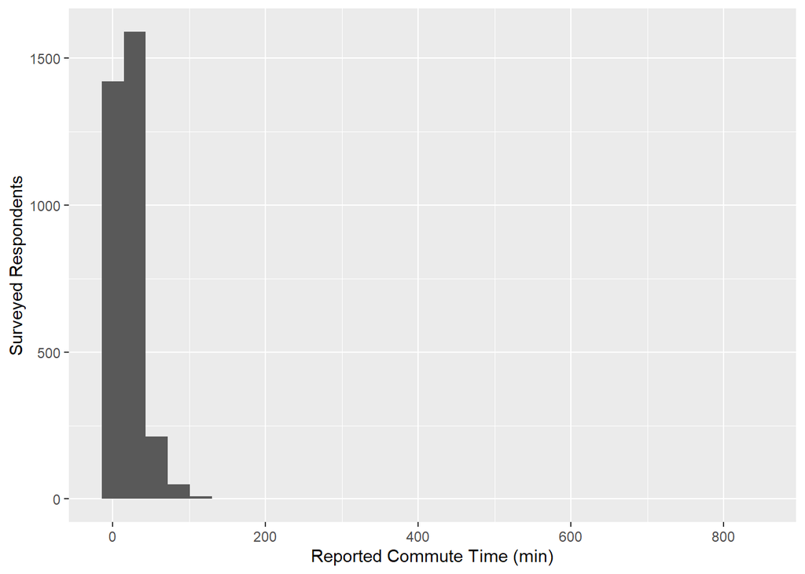

These statistics show outliers within the dataset. **These outliers have not yet been removed.**  
The person level commute distance data is aggregated to the household level (6,319):

- the average commute time (min) of the household individuals
- the total commute time (mi) of the household individuals

###### *Commute time (average)*

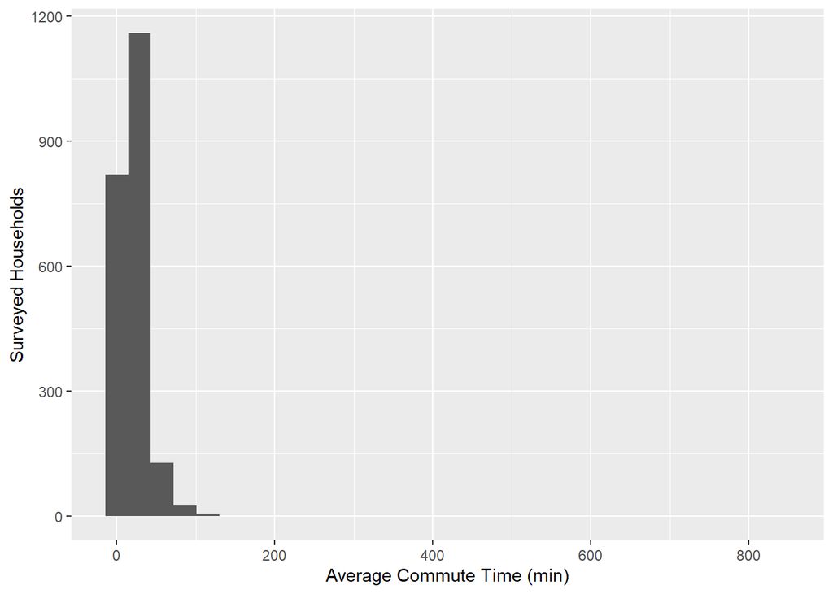

```
##                   Value  Std. Error    t value       p-value simp p-value
## explanatory  0.01847256 0.002466831   7.488376  6.973111e-14            0
## 0|1         -1.20956622 0.075151832 -16.094966  2.767213e-58            0
## 1|2          1.01808629 0.072969178  13.952278  3.047129e-44            0
## 2|3          2.80749760 0.099887766  28.106521 8.153802e-174            0
```

**Vehicle Ownership by Average Commute Time**

|  | *Dependent variable:* |
| --- | --- |
|  | outcome |
| explanatory | 0.018*** |
|  | (0.002) |
| Observations | 2,145 |
| *Note:* | <sup>⋆</sup>p<0.1; <sup>⋆⋆</sup>p<0.05; <sup>⋆⋆⋆</sup>p<0.01 |

There are fewer observations because of the 4,174 NA values - a result of using the `mean()`.

###### *Commute time (total)*

[figure not shown]

```
##                   Value  Std. Error   t value       p-value simp p-value
## explanatory  0.01257571 0.001036549  12.13229  7.122911e-34            0
## 0|1         -1.42759865 0.034362531 -41.54521  0.000000e+00            0
## 1|2          0.79903953 0.029679738  26.92205 1.212158e-159            0
## 2|3          2.65935979 0.050323717  52.84506  0.000000e+00            0
```

**Vehicle Ownership by Total Commute Time**

|  | *Dependent variable:* |
| --- | --- |
|  | outcome |
| explanatory | 0.013*** |
|  | (0.001) |
| Observations | 6,319 |
| *Note:* | <sup>⋆</sup>p<0.1; <sup>⋆⋆</sup>p<0.05; <sup>⋆⋆⋆</sup>p<0.01 |

Both average household commute time and the total household commute time are positively associated with household vehicle ownership. Although the coefficients are small, these variables are statistically significant.

##### *Commute Frequency*

Original data at a person level (11,940 survey respondents)

|  | Overall (N=11940) |
| --- | --- |
| commute_freq |  |
| 1 day a week | 72 (1%) |
| 2 days a week | 201 (2%) |
| 3 days a week | 471 (4%) |
| 4 days a week | 817 (7%) |
| 5 days a week | 4561 (38%) |
| 6-7 days a week | 432 (4%) |
| A few times per month | 85 (1%) |
| Less than monthly | 67 (1%) |
| Missing: Skip logic | 2475 (21%) |
| Missing | 2759 (23.1%) |

The commuting frequency data is aggregated to the household level. The following tables reflect the lowest and highest commuting frequencies of the individuals within each of the surveyed households (6,319).

```
## Frequencies
## person_and_household$hh_commute_freq_min
## Type: Numeric
##
##               Freq   % Valid   % Valid Cum.   % Total   % Total Cum.
## ----------- ------ --------- -------------- --------- --------------
##           1    147      3.05           3.05      2.33           2.33
##           2    708     14.71          17.76     11.20          13.53
##           3   3958     82.24         100.00     62.64          76.17
##        <NA>   1506                              23.83         100.00
##       Total   6319    100.00         100.00    100.00         100.00
```

```
## Frequencies
## person_and_household$hh_commute_freq_max
## Type: Numeric
##
##               Freq   % Valid   % Valid Cum.   % Total   % Total Cum.
## ----------- ------ --------- -------------- --------- --------------
##           1     88      1.83           1.83      1.39           1.39
##           2    366      7.60           9.43      5.79           7.18
##           3   4359     90.57         100.00     68.98          76.17
##        <NA>   1506                              23.83         100.00
##       Total   6319    100.00         100.00    100.00         100.00
```

###### *Commute frequency (min)*

Margin of Error

| commute_freq_simp_min | Percentage_0 | Percentage_1 | Percentage_2 | Percentage_3 | Total_0 | Total_1 | Total_2 | Total_3 | Count_0 | Count_1 | Count_2 | Count_3 | sample_size | MOE_Percent |
| --- | --- | --- | --- | --- | --- | --- | --- | --- | --- | --- | --- | --- | --- | --- |
| 3 or fewer days a week | 7.603457 | 16.23170 | 43.92529 | 32.23955 | 16389.4478 | 34987.855 | 94682.096 | 69493.19 | 86 | 290 | 259 | 73 | 708 | 3.091144 |
| 4 or more days a week | 5.558091 | 31.40983 | 39.38776 | 23.64432 | 54233.8662 | 306485.921 | 384331.737 | 230712.79 | 634 | 1944 | 1078 | 302 | 3958 | 1.307368 |
| Less than once a week | 1.766047 | 12.00088 | 15.83356 | 70.39952 | 914.0914 | 6211.556 | 8195.321 | 36438.22 | 15 | 71 | 40 | 21 | 147 | 6.783866 |
| NA | 14.058373 | 39.83759 | 33.28564 | 12.81839 | 58156.5773 | 164799.870 | 137695.815 | 53027.04 | 376 | 728 | 304 | 98 | 1506 | 2.119451 |

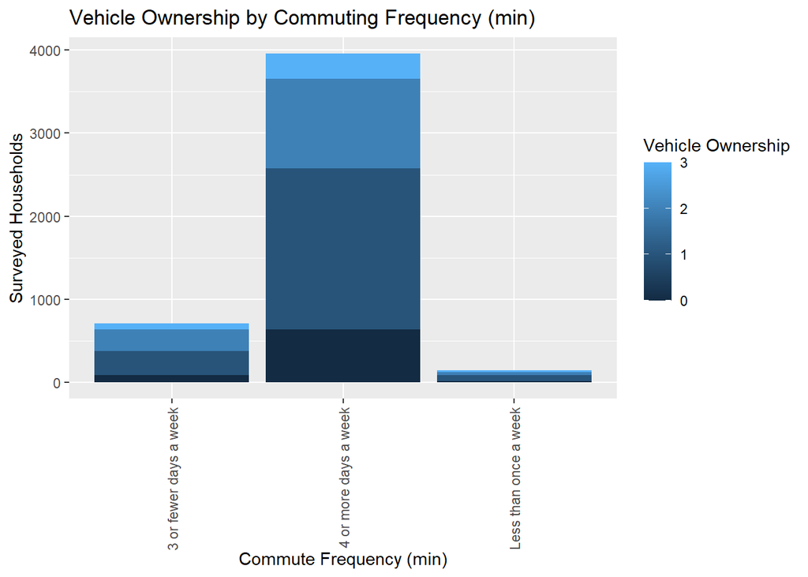

Reference group: 3 or fewer days a week

```
##                                        Value Std. Error     t value
## explanatory4 or more days a week -0.43986835 0.07594890  -5.7916355
## explanatoryLess than once a week -0.04638153 0.16919773  -0.2741262
## 0|1                              -2.08622854 0.07773678 -26.8370835
## 1|2                               0.17883348 0.07052729   2.5356635
## 2|3                               2.06119221 0.08104482  25.4327441
##                                        p-value simp p-value
## explanatory4 or more days a week  6.970428e-09       0.0000
## explanatoryLess than once a week  7.839876e-01       0.7840
## 0|1                              1.193583e-158       0.0000
## 1|2                               1.122345e-02       0.0112
## 2|3                              1.095791e-142       0.0000
```

**Vehicle Ownership by Commuting Frequency (min)**

|  | *Dependent variable:* |
| --- | --- |
|  | outcome |
| explanatory4 or more days a week | -0.440*** |
|  | (0.076) |
| explanatoryLess than once a week | -0.046 |
|  | (0.169) |
| Observations | 4,813 |
| *Note:* | <sup>⋆</sup>p<0.1; <sup>⋆⋆</sup>p<0.05; <sup>⋆⋆⋆</sup>p<0.01 |

###### *Commute frequency (max)*

Margin of Error

| commute_freq_simp_max | Percentage_0 | Percentage_1 | Percentage_2 | Percentage_3 | Total_0 | Total_1 | Total_2 | Total_3 | Count_0 | Count_1 | Count_2 | Count_3 | sample_size | MOE_Percent |
| --- | --- | --- | --- | --- | --- | --- | --- | --- | --- | --- | --- | --- | --- | --- |
| 3 or fewer days a week | 12.360138 | 23.99200 | 42.20951 | 21.43835 | 11528.619 | 22377.952 | 39369.900 | 19996.103 | 62 | 186 | 91 | 27 | 366 | 4.299276 |
| 4 or more days a week | 5.214926 | 28.20627 | 39.19538 | 27.38342 | 59217.224 | 320291.666 | 445076.630 | 310947.873 | 662 | 2064 | 1268 | 365 | 4359 | 1.245783 |
| Less than once a week | 5.546986 | 35.14834 | 19.35949 | 39.94518 | 791.562 | 5015.713 | 2762.624 | 5700.229 | 11 | 55 | 18 | 4 | 88 | 8.767879 |
| NA | 14.058373 | 39.83759 | 33.28564 | 12.81839 | 58156.577 | 164799.870 | 137695.815 | 53027.037 | 376 | 728 | 304 | 98 | 1506 | 2.119451 |

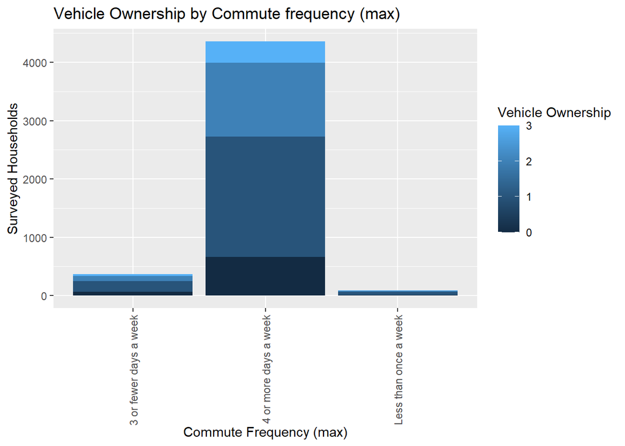

Reference group: 3 or fewer days a week

```
##                                       Value Std. Error     t value
## explanatory4 or more days a week  0.1904569 0.10170984   1.8725516
## explanatoryLess than once a week -0.1109637 0.21564864  -0.5145578
## 0|1                              -1.5449738 0.10139578 -15.2370616
## 1|2                               0.7097483 0.09879922   7.1837433
## 2|3                               2.5838512 0.10824238  23.8709762
##                                        p-value simp p-value
## explanatory4 or more days a week  6.113033e-02       0.0611
## explanatoryLess than once a week  6.068621e-01       0.6069
## 0|1                               2.006952e-52       0.0000
## 1|2                               6.782815e-13       0.0000
## 2|3                              6.133513e-126       0.0000
```

**Vehicle Ownership by Commute frequency (max)**

|  | *Dependent variable:* |
| --- | --- |
|  | outcome |
| explanatory4 or more days a week | 0.190* |
|  | (0.102) |
| explanatoryLess than once a week | -0.111 |
|  | (0.216) |
| Observations | 4,813 |
| *Note:* | <sup>⋆</sup>p<0.1; <sup>⋆⋆</sup>p<0.05; <sup>⋆⋆⋆</sup>p<0.01 |

Household commute frequency does not have a clear relationship with household vehicle ownership based on the aggregation techniques.  
* When analyzing households by the individuals with the least frequent commute, those commuting less than once a week (not statistically significant) and those working 4 or more times a week (statistically significant, p<0.001) have fewer household vehicles than households with an individual commuting 3 or fewer days a week.  
* When analyzing households by the individual with the most frequent commute, those commuting less than once a week have fewer household vehicles (not statistically significant)than households with an individual commuting 3 or fewer days a week. Households commuting 4 or more times a week have more household vehicles (statistically significant, p<0.1).  
The reason that the households with individuals commuting less than once a week represents a very small sample of the total surveyed households (~2%, 147/6,319).

##### *Household Commute Trips*

This variable measures the number of commute trips that occur within a household by the number of commute trips that would be anticipated for the number of workers within a household. This variable was calculated by dividing the sum of household commute trips per week by the number of workers within the household multiplied by 5 (sum of household commute trips/(numworkers*5)). This value assumes that most workers commute 5 days a week.  
Aggregated data at a household level (6,319 survey respondents).

```
##    Min. 1st Qu.  Median    Mean 3rd Qu.    Max.
##  0.0000  0.0000  0.5000  0.3806  0.5333  0.9000
```

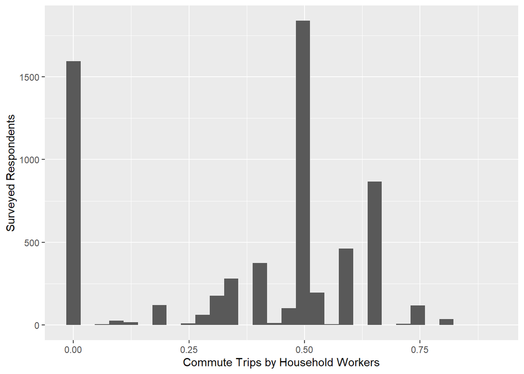

```
##                 Value Std. Error   t value       p-value simp p-value
## explanatory  1.022688 0.09619087  10.63186  2.118421e-26            0
## 0|1         -1.174734 0.04742627 -24.76969 1.902637e-135            0
## 1|2          1.047184 0.04677304  22.38863 5.079328e-111            0
## 2|3          2.885266 0.06194307  46.57932  0.000000e+00            0
```

**Vehicle Ownership by Trips:Worker Ratio**

|  | *Dependent variable:* |
| --- | --- |
|  | outcome |
| explanatory | 1.023*** |
|  | (0.096) |
| Observations | 6,319 |
| *Note:* | <sup>⋆</sup>p<0.1; <sup>⋆⋆</sup>p<0.05; <sup>⋆⋆⋆</sup>p<0.01 |

The number of commute trips by workers within the household is positively associated with higher household vehicle ownership. This relationship is statistically significant.

#### *12. Transit accessibility*

Transit accessibility is measured at a census block geographic scale. These values are calculated using the transit score methodology (https://www.walkscore.com/transit-score-methodology.shtml) and are scaled by determining the log of the highest score (downtown Seattle) and the minimum score above 0. Higher values indicate greater transit accessibility.  
Because the scores are by census block and survey respondents provided their home locations, this variable measures transit accessibility based on housing location (instead of work location). Work location is not considered in this analysis because it is at a person-level, instead of a household-level. **Future work could take the average of the transit scores associated with household members’ work locations.**  
*For more information about the generation of the raw or scaled block group transit scores, please contact Stefan Coe.*

```
##    Min. 1st Qu.  Median    Mean 3rd Qu.    Max.    NA's
##    0.00   51.51   66.25   63.21   80.42   99.79     310
```

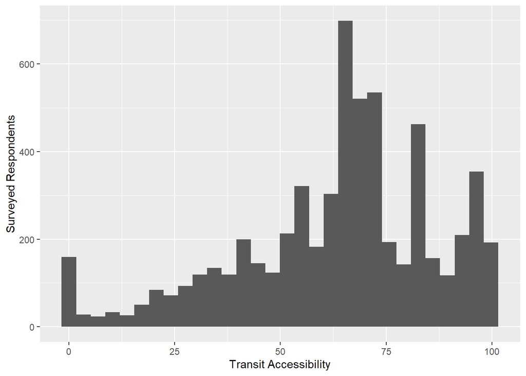

```
##                   Value  Std. Error    t value       p-value simp p-value
## explanatory -0.04395877 0.001197741 -36.701403 6.936355e-295            0
## 0|1         -4.54498767 0.093672256 -48.520105  0.000000e+00            0
## 1|2         -1.89774854 0.076523227 -24.799641 9.045256e-136            0
## 2|3          0.34240378 0.078027188   4.388262  1.142599e-05            0
```

**Vehicle Ownership by Household Transit Accessibility**

|  | *Dependent variable:* |
| --- | --- |
|  | outcome |
| explanatory | -0.044*** |
|  | (0.001) |
| Observations | 6,009 |
| *Note:* | <sup>⋆</sup>p<0.1; <sup>⋆⋆</sup>p<0.05; <sup>⋆⋆⋆</sup>p<0.01 |

Transit accessibility is negatively associated with household vehicle ownership, with households living in block groups with higher access to transit owning fewer household vehicles. This relationship is statistically significant.

#### *13. Proximity to jobs and services*

Proximity to services is based on a displacement risk index created by PSRC. Although there are a number of variables that were explored to create the index, this analysis will include the following:

- jobs accessible by automobile (30min)
- jobs accessible by transit (45m)
- distance to a supermarket (mi)
- distance to a school (mi)

*other variables not included in this analysis: distance to pharmacies, restaurants, parks*

##### *Jobs accessible by automobile (30min)*

```
##    Min. 1st Qu.  Median    Mean 3rd Qu.    Max.
##   0.800   1.300   1.300   1.322   1.400   1.400
```

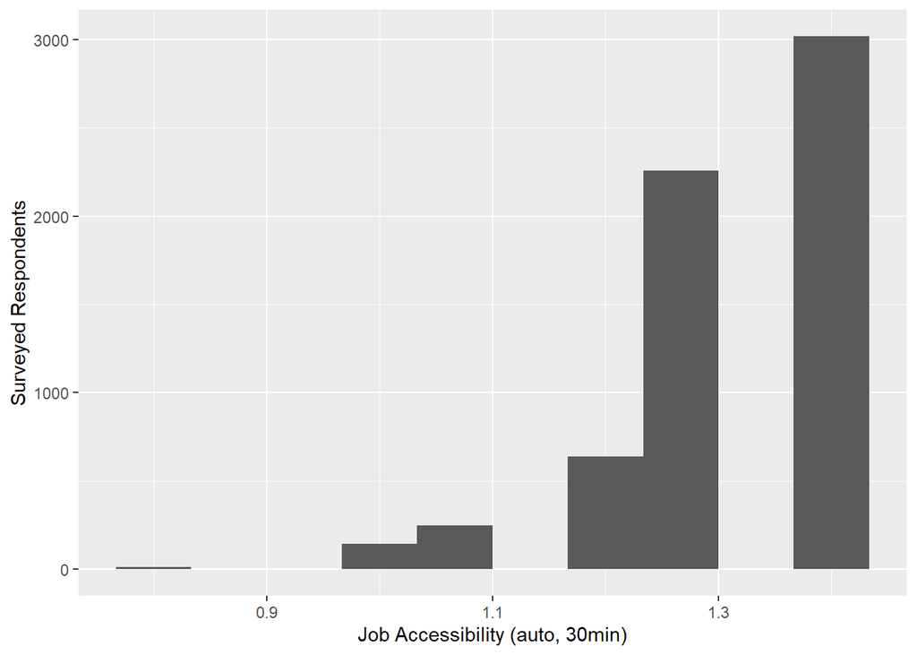

```
##                  Value Std. Error   t value       p-value simp p-value
## explanatory  -8.180236  0.2710743 -30.17709 4.733003e-200            0
## 0|1         -12.525535  0.3676004 -34.07378 1.804527e-254            0
## 1|2         -10.110799  0.3569554 -28.32511 1.696121e-176            0
## 2|3          -8.061351  0.3474000 -23.20481 4.071422e-119            0
```

**Vehicle Ownership by Job Accessibility (auto)**

|  | *Dependent variable:* |
| --- | --- |
|  | outcome |
| explanatory | -8.180*** |
|  | (0.271) |
| Observations | 6,319 |
| *Note:* | <sup>⋆</sup>p<0.1; <sup>⋆⋆</sup>p<0.05; <sup>⋆⋆⋆</sup>p<0.01 |

##### *Jobs accessible by transit (45min)*

```
##    Min. 1st Qu.  Median    Mean 3rd Qu.    Max.
##   0.000   1.100   1.300   1.163   1.300   1.300
```

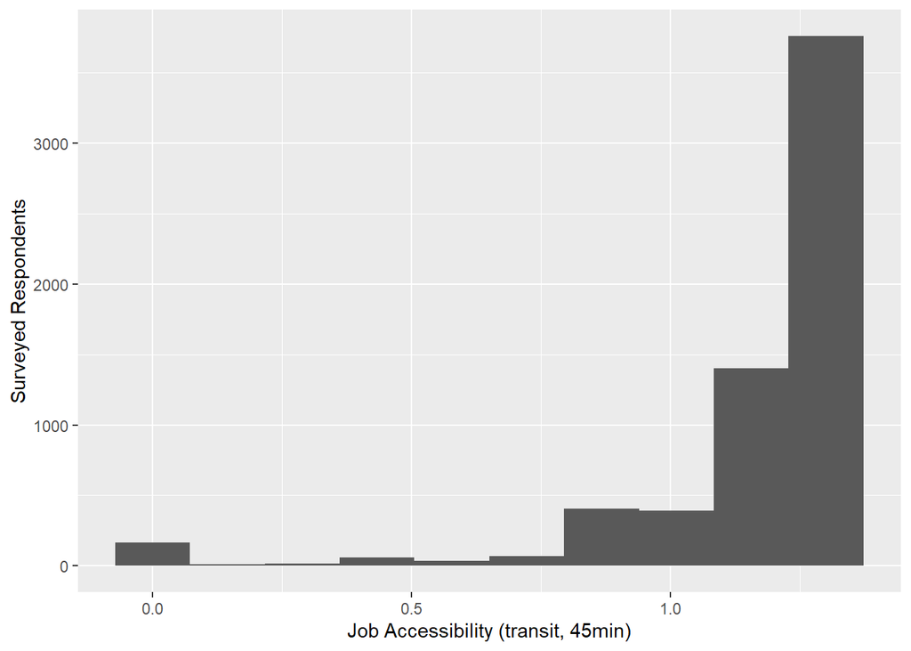

```
##                  Value Std. Error    t value       p-value simp p-value
## explanatory -2.9848570  0.1052814 -28.351227 8.083495e-177            0
## 0|1         -5.1646517  0.1333679 -38.724859  0.000000e+00            0
## 1|2         -2.8066316  0.1253460 -22.391079 4.808073e-111            0
## 2|3         -0.7094781  0.1187847  -5.972806  2.332075e-09            0
```

**Vehicle Ownership by Job Accessibility (transit)**

|  | *Dependent variable:* |
| --- | --- |
|  | outcome |
| explanatory | -2.985*** |
|  | (0.105) |
| Observations | 6,319 |
| *Note:* | <sup>⋆</sup>p<0.1; <sup>⋆⋆</sup>p<0.05; <sup>⋆⋆⋆</sup>p<0.01 |

##### *Distance to a supermarket*

```
##    Min. 1st Qu.  Median    Mean 3rd Qu.    Max.
##  0.0500  0.1900  0.3300  0.4982  0.5700  8.7800
```

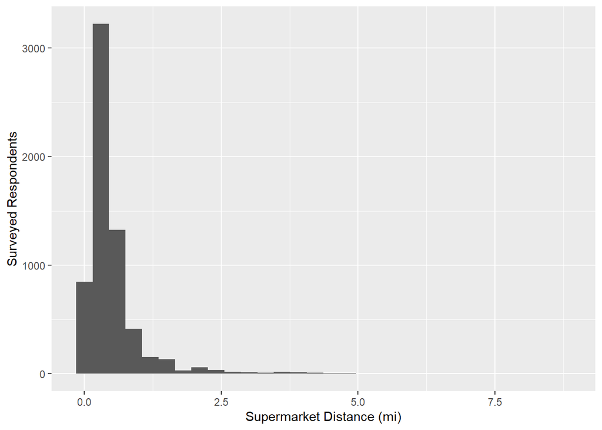

```
##                  Value Std. Error   t value       p-value simp p-value
## explanatory  1.4366606 0.05680982  25.28895 4.226353e-141            0
## 0|1         -0.9757544 0.03934664 -24.79892 9.207572e-136            0
## 1|2          1.3784118 0.03938723  34.99641 2.551285e-268            0
## 2|3          3.4513688 0.06467950  53.36109  0.000000e+00            0
```

**Vehicle Ownership by Distance to a Supermarket**

|  | *Dependent variable:* |
| --- | --- |
|  | outcome |
| explanatory | 1.437*** |
|  | (0.057) |
| Observations | 6,319 |
| *Note:* | <sup>⋆</sup>p<0.1; <sup>⋆⋆</sup>p<0.05; <sup>⋆⋆⋆</sup>p<0.01 |

##### *Distance to a school*

```
##    Min. 1st Qu.  Median    Mean 3rd Qu.    Max.
##  0.0900  0.3500  0.4600  0.5712  0.6500  8.3000
```

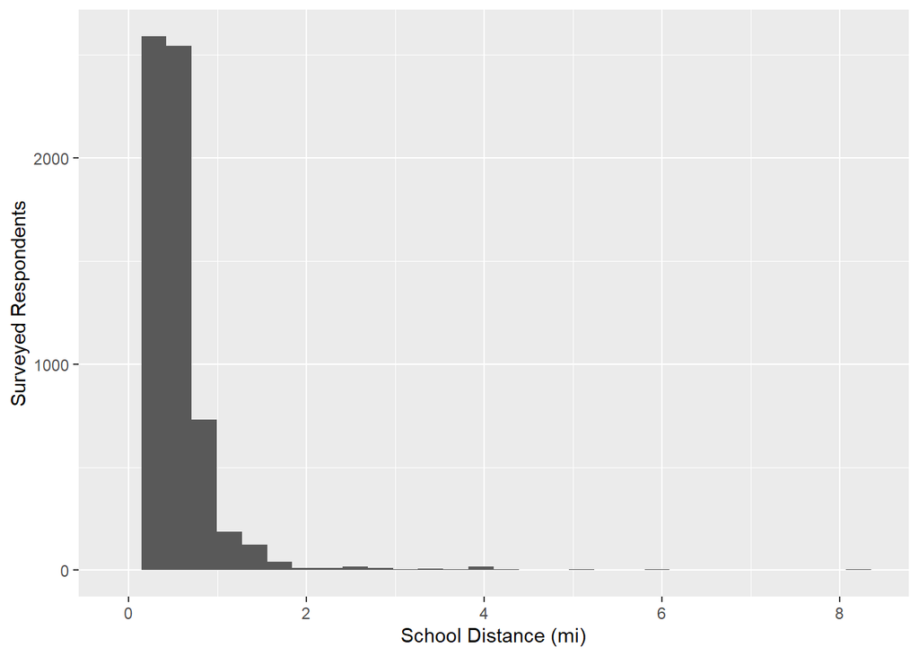

```
##                  Value Std. Error   t value       p-value simp p-value
## explanatory  0.8409372 0.05934364  14.17064  1.392316e-45            0
## 0|1         -1.1059719 0.04491409 -24.62416 6.962565e-134            0
## 1|2          1.1229173 0.04296093  26.13810 1.345641e-150            0
## 2|3          3.0144946 0.06233337  48.36085  0.000000e+00            0
```

**Vehicle Ownership by Distance to a school**

|  | *Dependent variable:* |
| --- | --- |
|  | outcome |
| explanatory | 0.841*** |
|  | (0.059) |
| Observations | 6,319 |
| *Note:* | <sup>⋆</sup>p<0.1; <sup>⋆⋆</sup>p<0.05; <sup>⋆⋆⋆</sup>p<0.01 |

Overall, the relationship between proximity to jobs and services and household vehicle ownership is statistically significant.  
* **job accessibility** + *by automobile (30min)*: Higher jobs accessibility by automobile is associated with lower vehicle ownership  
+ *by transit (45m)*: Higher job accessibility by transit is associated with lower vehicle ownership, weaker relationship when compared to job accessibility by auto  
* **distance to services (mi)**  
+ *supermarket*: Farther distance between house and supermarket is associated with higher vehicle ownership  
+ *school*: Farther distance between house and school is associated with higher vehicle ownership, weaker relationship when compared to supermarket distance

### b. Overview: univariate analysis results

The table below shows which explanatory variables were statistically significant when analyzed against household vehicle ownership. Significance: *p<0.1; ***p<0.05; ***p<0.01

Explanatory variables

Significance

Trend (higher household vehicle ownership)

1. Income

***

higher income

2. Age/Lifecycle

***

households with children and older individuals

3. Household size

***

larger households

4. Number of household licenses

***

higher number of household licenses

5. Number of workers

***

higher number of workers

6. Number of jobs

***

higher jobs:workers ratio

7. Educational Attainment

***

*depends on aggregation technique*

8. Race

** and ***

white only households

9. Housing

** and ***

households that own and live in single-family detached homes

10. Housing location

***

11. Commute patterns

* and ***

farther commute distances, longer commute times, households with more commute trips/worker

12. Transit accessibility

***

lower transit accessibility

13. Proximity to jobs and services

***

lower job accessibility, reduced proximity to services

## 4. Correlation matrix with all variables

The outcome variable is vehicle ownership (`vehicle_group`: 0, 1, 2, 3+).  
The explanatory variables can be categorized as **categorical** and *numeric*. The reference group is provided for the categorical variables.

**1. Income : Under $25k is reference**  
**2. Age/Lifecycle : Under age 35**  
*3. Household size*  
*4. Number of household licenses*  
*5. Number of workers*  
*6. Number of jobs*  
**7. Educational Attainment : Bachelor degree**  
**8. Race : White Only**  
**9. Housing : (1) Own/paying mortgage; (2) Apartment/condo**  
**10. Housing location : Not RGC**  
**11. Commute patterns : 3 or fewer days a week (frequency)**  
*12. Transit accessibility*  
*13. Proximity to jobs and services*

The correlation matrix table will illustrate relationships or associations between the variables. The coefficient indicates the strength of the relationship and the direction of the correlation (positive or negative). This analysis represents a subset of the variables - numerical, not categorical.

**Correlations between the different variables**

```
##                      hhsize_simp_num driver_simp numworkers_simp
## hhsize_simp_num                    1
## driver_simp                    0.812           1
## numworkers_simp                0.478       0.479               1
## jobs_numworkers                0.245       0.259           0.737
## hh_com_auto_time_avg               0       0.069           0.035
## hh_com_auto_time_sum           0.189       0.084           0.265
## hh_commutetrips                0.244       0.268           0.704
## scaled_score                  -0.299      -0.281          -0.042
## ln_jobs_auto_30               -0.207      -0.178           0.038
## ln_jobs_transit_45            -0.209      -0.177           0.046
## dist_super                     0.193       0.198          -0.011
## dist_school                    0.092       0.083          -0.062
##                      jobs_numworkers hh_com_auto_time_avg hh_com_auto_time_sum
## hhsize_simp_num
## driver_simp
## numworkers_simp
## jobs_numworkers                    1
## hh_com_auto_time_avg           0.016                    1
## hh_com_auto_time_sum           0.162                 0.86                    1
## hh_commutetrips                0.594               -0.022                0.206
## scaled_score                   0.013               -0.177               -0.102
## ln_jobs_auto_30                0.073               -0.214               -0.121
## ln_jobs_transit_45             0.085               -0.159               -0.109
## dist_super                     -0.04                0.214                0.104
## dist_school                   -0.072                  0.1                0.038
##                      hh_commutetrips scaled_score ln_jobs_auto_30
## hhsize_simp_num
## driver_simp
## numworkers_simp
## jobs_numworkers
## hh_com_auto_time_avg
## hh_com_auto_time_sum
## hh_commutetrips                    1
## scaled_score                   0.022            1
## ln_jobs_auto_30                0.091        0.763               1
## ln_jobs_transit_45             0.093        0.786           0.791
## dist_super                    -0.058       -0.699          -0.626
## dist_school                   -0.082       -0.328          -0.508
##                      ln_jobs_transit_45 dist_super dist_school
## hhsize_simp_num
## driver_simp
## numworkers_simp
## jobs_numworkers
## hh_com_auto_time_avg
## hh_com_auto_time_sum
## hh_commutetrips
## scaled_score
## ln_jobs_auto_30
## ln_jobs_transit_45                    1
## dist_super                       -0.743          1
## dist_school                      -0.617      0.655           1
```

**Significance levels (p-values)**

```
##                      hhsize_simp_num driver_simp numworkers_simp
## hhsize_simp_num                   NA       0.000           0.000
## driver_simp                    0.000          NA           0.000
## numworkers_simp                0.000       0.000              NA
## jobs_numworkers                0.000       0.000           0.000
## hh_com_auto_time_avg           0.992       0.001           0.101
## hh_com_auto_time_sum           0.000       0.000           0.000
## hh_commutetrips                0.000       0.000           0.000
## scaled_score                   0.000       0.000           0.001
## ln_jobs_auto_30                0.000       0.000           0.003
## ln_jobs_transit_45             0.000       0.000           0.000
## dist_super                     0.000       0.000           0.395
## dist_school                    0.000       0.000           0.000
##                      jobs_numworkers hh_com_auto_time_avg hh_com_auto_time_sum
## hhsize_simp_num                0.000                0.992                0.000
## driver_simp                    0.000                0.001                0.000
## numworkers_simp                0.000                0.101                0.000
## jobs_numworkers                   NA                0.468                0.000
## hh_com_auto_time_avg           0.468                   NA                0.000
## hh_com_auto_time_sum           0.000                0.000                   NA
## hh_commutetrips                0.000                0.314                0.000
## scaled_score                   0.309                0.000                0.000
## ln_jobs_auto_30                0.000                0.000                0.000
## ln_jobs_transit_45             0.000                0.000                0.000
## dist_super                     0.002                0.000                0.000
## dist_school                    0.000                0.000                0.002
##                      hh_commutetrips scaled_score ln_jobs_auto_30
## hhsize_simp_num                0.000        0.000           0.000
## driver_simp                    0.000        0.000           0.000
## numworkers_simp                0.000        0.001           0.003
## jobs_numworkers                0.000        0.309           0.000
## hh_com_auto_time_avg           0.314        0.000           0.000
## hh_com_auto_time_sum           0.000        0.000           0.000
## hh_commutetrips                   NA        0.094           0.000
## scaled_score                   0.094           NA           0.000
## ln_jobs_auto_30                0.000        0.000              NA
## ln_jobs_transit_45             0.000        0.000           0.000
## dist_super                     0.000        0.000           0.000
## dist_school                    0.000        0.000           0.000
##                      ln_jobs_transit_45 dist_super dist_school
## hhsize_simp_num                       0      0.000       0.000
## driver_simp                           0      0.000       0.000
## numworkers_simp                       0      0.395       0.000
## jobs_numworkers                       0      0.002       0.000
## hh_com_auto_time_avg                  0      0.000       0.000
## hh_com_auto_time_sum                  0      0.000       0.002
## hh_commutetrips                       0      0.000       0.000
## scaled_score                          0      0.000       0.000
## ln_jobs_auto_30                       0      0.000       0.000
## ln_jobs_transit_45                   NA      0.000       0.000
## dist_super                            0         NA       0.000
## dist_school                           0      0.000          NA
```

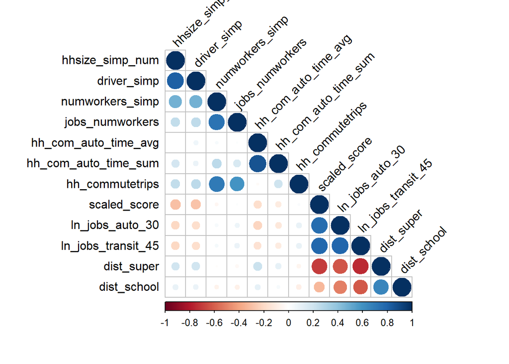

## 5. Ordered Logit Model

```
##                                                    Value  Std. Error
## hhincomeb_reordered$25,000-$49,999          0.7253784099 0.291689802
## hhincomeb_reordered$50,000-$74,999          1.0330512099 0.290398932
## hhincomeb_reordered$75,000-$99,999          1.0997571907 0.295374713
## hhincomeb_reordered$100,000 or more         1.1865521741 0.285883709
## hhincomeb_reorderedPrefer not to answer     0.6737900792 0.358896947
## hh_lifecycleAge 35-64                       0.3862286787 0.125766020
## hh_lifecycleAge 65+                         0.7762438111 0.249096893
## hh_lifecycleWith children under 5           0.6659746373 0.270611094
## hh_lifecycleWith children age 5-17          0.9554133155 0.256121975
## hhsize_simp_num                            -0.1290597232 0.123747856
## driver_simp                                 2.0368656369 0.147785958
## numworkers_simp                            -0.1000917501 0.149839223
## jobs_numworkers                             0.1114485283 0.271947537
## hh_edu_min_simphigh school                  0.2826090110 0.238413862
## hh_edu_min_simppost-graduate                0.1194491227 0.156896713
## hh_edu_min_simpspecialized, <4y             0.4064718153 0.165605092
## hh_edu_max_simpHigh school                 -0.0927201642 0.405915732
## hh_edu_max_simpPost-graduate               -0.1899071703 0.141223588
## hh_edu_max_simpSpecialized, <4y            -0.3781045871 0.199438793
## hh_race_2People of Color                   -0.1085526311 0.135996650
## hh_race_2Missing/Other                      0.2227728353 0.150093629
## hh_race_3People of Color                    0.0929699425 0.204392203
## rent_own_simpRent                          -0.4174773855 0.139569412
## rent_own_simpOther                          0.5131477109 0.396301957
## restype_simpOther                           0.6429111028 0.567644000
## restype_simpSingle-family                   0.7527094040 0.159355258
## restype_simpTownhouse                       0.1656117759 0.195944273
## RGC_binaryRGC                              -0.2815780188 0.141525851
## hh_com_auto_time_avg                        0.0007724634 0.004308098
## hh_com_auto_time_sum                        0.0017121233 0.003138507
## commute_freq_simp_min4 or more days a week  0.0143578701 0.186670105
## commute_freq_simp_minLess than once a week  1.1735668679 0.420276885
## commute_freq_simp_max4 or more days a week  0.0300857080 0.267920959
## commute_freq_simp_maxLess than once a week -0.6792660799 0.600445440
## hh_commutetrips                             0.4880247759 0.532335173
## scaled_score                               -0.0292704562 0.004605610
## ln_jobs_auto_30                            -1.2339230008 0.956611915
## ln_jobs_transit_45                          0.4036564022 0.509015609
## dist_super                                  0.1436796277 0.209462188
```

[output cut: 33 more lines]

```
## hh_com_auto_time_avg                        0.17930496    0.86
## hh_com_auto_time_sum                        0.54552165    0.59
## commute_freq_simp_min4 or more days a week  0.07691574    0.94
## commute_freq_simp_minLess than once a week  2.79236596    0.01
## commute_freq_simp_max4 or more days a week  0.11229322    0.91
## commute_freq_simp_maxLess than once a week -1.13127028    0.26
## hh_commutetrips                             0.91676222    0.36
## scaled_score                               -6.35539180    0.00
## ln_jobs_auto_30                            -1.28988881    0.20
## ln_jobs_transit_45                          0.79301380    0.43
## dist_super                                  0.68594542    0.49
## dist_school                                -1.88799142    0.06
## 0|1                                         0.57890186    0.56
## 1|2                                         3.82651498    0.00
## 2|3                                         6.40674833    0.00
```

[output not shown]

[output cut: 53 more lines]